# Attitudes toward equality - part 2

### 1.2.2 Categorical variables

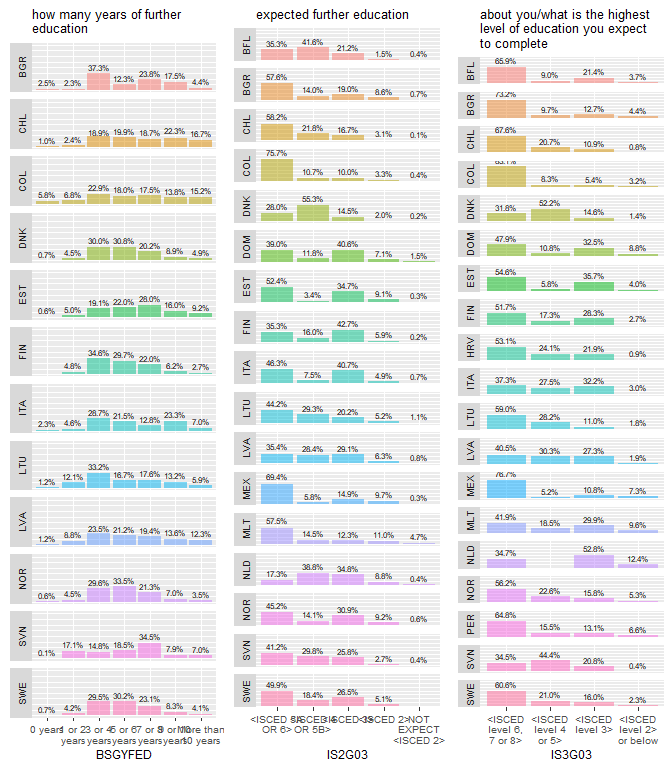

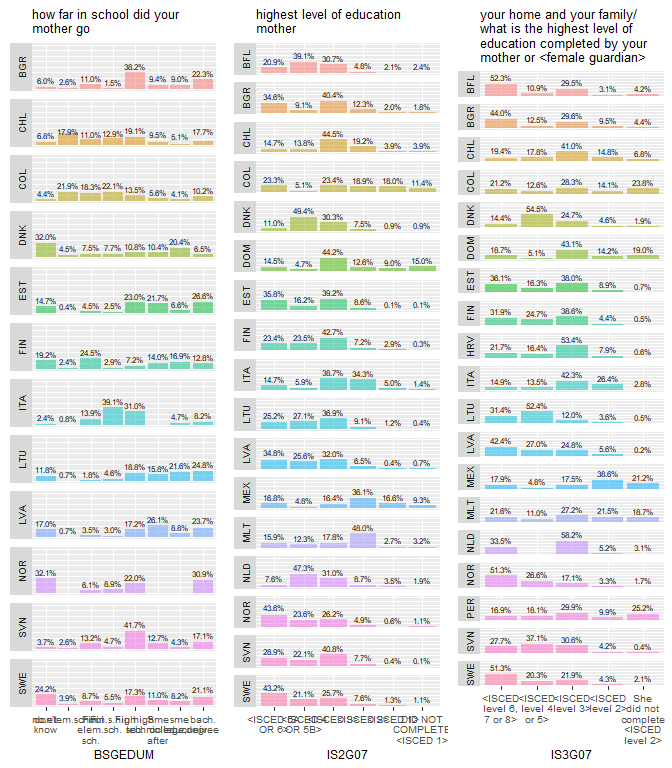

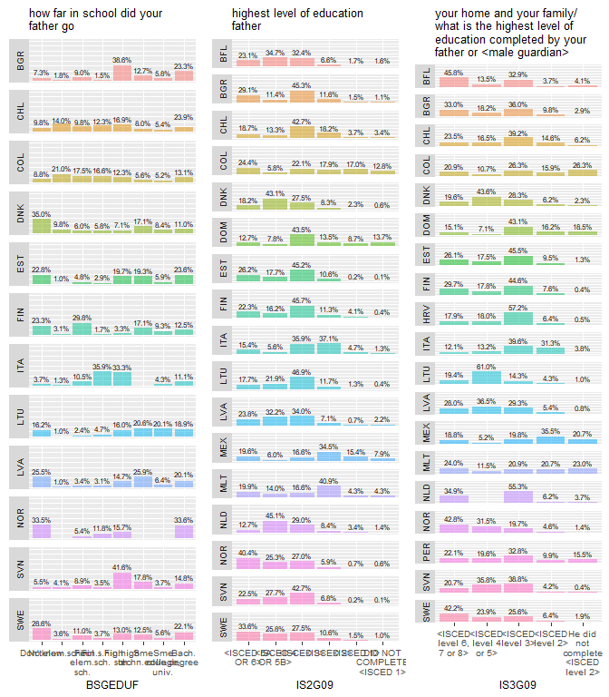

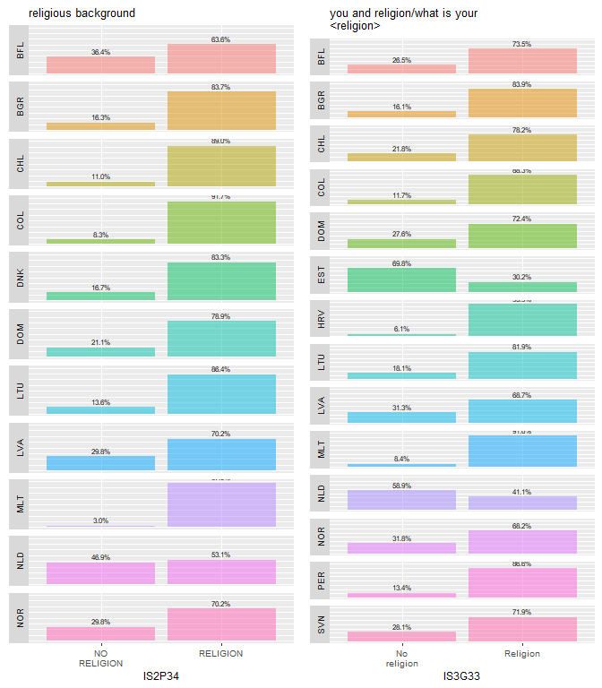

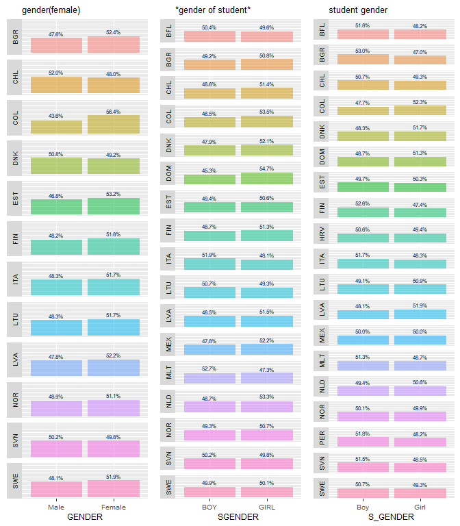

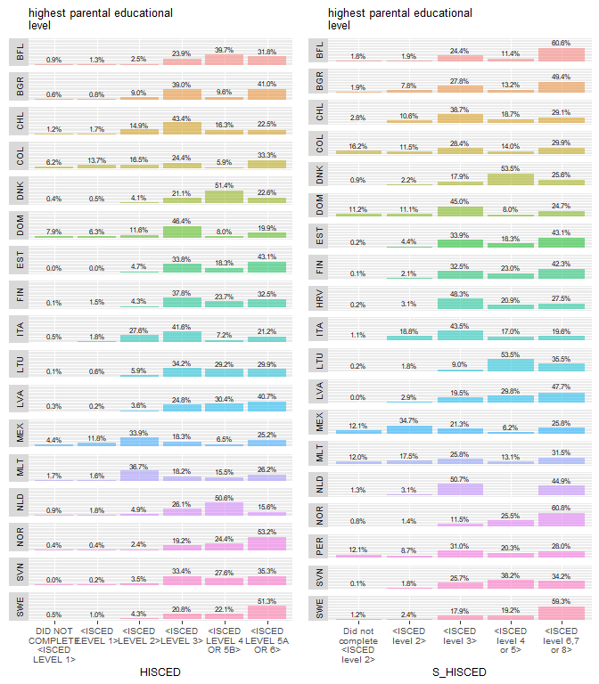

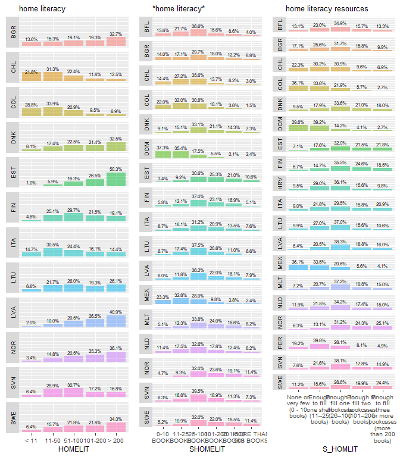

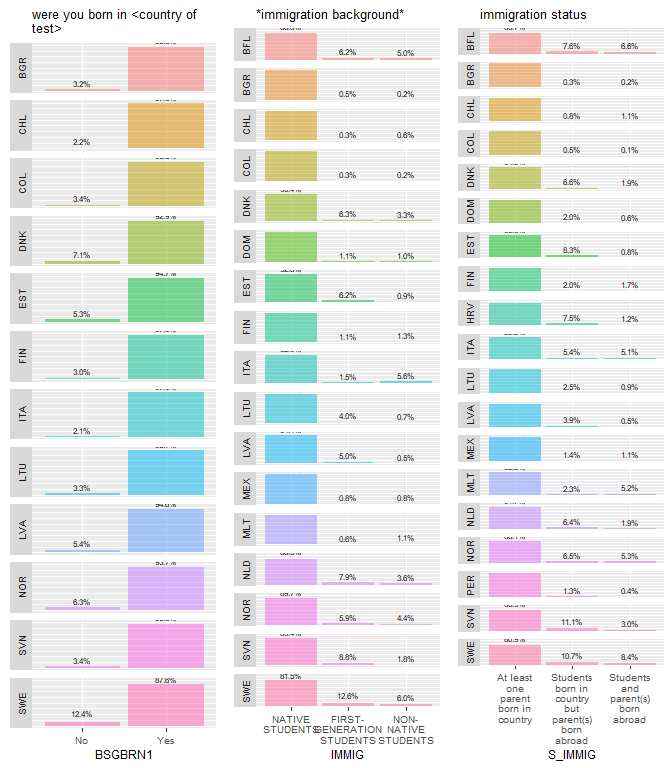

# 2 Multilevel modelling (MLM)

In this section a multilevel model was performed to evaluate the variability of the scale considering the nested structure of the data. The first model use the three cycles of CIVED/ICCS as a level, followed by Country level and finally School level. Next, The analysis is performed to all countries participating in each cycle separately, using country and school level. Results are obtained for the models indicated using Null model followed by the model with some explanatory variables at the student level.

Dependant variables:

Ethn_Equal: Attitudes toward equal rights for all ethnic or racial groups calculated by CFA (min = 0, max = 100)  
Gend_Equal: Attitudes toward gender equality calculated by CFA (min = 0, max = 100) Immi_Equal: Attitudes toward equal rights for immigrants calculated by CFA (min = 0, max = 100)

The function used is $lmer(Dep ~ Indep + (1|cycle) + (1|cycle:COUNTRY) + (1|cycle:COUNTRY:IDSCHOOL), data=data, weights=SENWGT, REML=FALSE)$ for the three level model and $lmer(Dep ~ Indep + (1|COUNTRY) + (1|COUNTRY:IDSCHOOL), data=data, weights=SENWGT, REML=FALSE)$ for the two level model.

## 2.1 Two level model: School nested in countries by cycles

### 2.1.1 Null model

Attitudes toward equal rights for immigrants

CIVED 1999

ICCS 2009

ICCS 2016

Predictors

Estimates

Estimates

Estimates

(Intercept)

30.03 ***  
(27.71 – 32.35)

27.45 ***  
(25.25 – 29.65)

26.66 ***  
(24.24 – 29.08)

Random Effects

σ<sup>2</sup>

75.35

75.53

75.96

τ<sub>00</sub>

25.43 <sub>COUNTRY:IDSCHOOL</sub>

19.97 <sub>COUNTRY:IDSCHOOL</sub>

24.37 <sub>COUNTRY:IDSCHOOL</sub>

16.56 <sub>COUNTRY</sub>

21.15 <sub>COUNTRY</sub>

21.10 <sub>COUNTRY</sub>

ICC

0.36

0.35

0.37

N

12 <sub>COUNTRY</sub>

17 <sub>COUNTRY</sub>

14 <sub>COUNTRY</sub>

528 <sub>IDSCHOOL</sub>

407 <sub>IDSCHOOL</sub>

185 <sub>IDSCHOOL</sub>

Observations

41788

61894

51042

Marginal R<sup>2</sup> / Conditional R<sup>2</sup>

0.000 / 0.358

0.000 / 0.352

0.000 / 0.374

- p<0.05 ** p<0.01 *** p<0.001

Attitudes toward gender equality

CIVED 1999

ICCS 2009

ICCS 2016

Predictors

Estimates

Estimates

Estimates

(Intercept)

25.15 ***  
(22.56 – 27.74)

15.41 ***  
(13.93 – 16.89)

12.87 ***  
(11.33 – 14.41)

Random Effects

σ<sup>2</sup>

66.01

69.19

31.05

τ<sub>00</sub>

20.32 <sub>COUNTRY:IDSCHOOL</sub>

18.14 <sub>COUNTRY:IDSCHOOL</sub>

13.86 <sub>COUNTRY:IDSCHOOL</sub>

20.68 <sub>COUNTRY</sub>

9.46 <sub>COUNTRY</sub>

11.59 <sub>COUNTRY</sub>

ICC

0.38

0.29

0.45

N

12 <sub>COUNTRY</sub>

17 <sub>COUNTRY</sub>

19 <sub>COUNTRY</sub>

528 <sub>IDSCHOOL</sub>

407 <sub>IDSCHOOL</sub>

213 <sub>IDSCHOOL</sub>

Observations

41788

61894

75895

Marginal R<sup>2</sup> / Conditional R<sup>2</sup>

0.000 / 0.383

0.000 / 0.285

0.000 / 0.450

- p<0.05 ** p<0.01 *** p<0.001

Attitudes toward equal rights for all ethnic/racial groups

CIVED 1999

ICCS 2009

ICCS 2016

Predictors

Estimates

Estimates

Estimates

(Intercept)

27.67 ***  
(25.49 – 29.84)

21.99 ***  
(20.04 – 23.95)

20.33 ***  
(18.92 – 21.75)

*SCHOOL ID*

*Reference*

*Reference*

*Reference*

Random Effects

σ<sup>2</sup>

64.67

74.82

50.97

τ<sub>00</sub>

20.07 <sub>COUNTRY:IDSCHOOL</sub>

17.16 <sub>COUNTRY:IDSCHOOL</sub>

17.97 <sub>COUNTRY:IDSCHOOL</sub>

14.57 <sub>COUNTRY</sub>

16.72 <sub>COUNTRY</sub>

9.69 <sub>COUNTRY</sub>

ICC

0.35

0.31

0.35

N

12 <sub>COUNTRY</sub>

17 <sub>COUNTRY</sub>

19 <sub>COUNTRY</sub>

528 <sub>IDSCHOOL</sub>

407 <sub>IDSCHOOL</sub>

213 <sub>IDSCHOOL</sub>

Observations

41788

61894

75895

Marginal R<sup>2</sup> / Conditional R<sup>2</sup>

0.000 / 0.349

0.000 / 0.312

0.000 / 0.352

- p<0.05 ** p<0.01 *** p<0.001

### 2.1.2 Model with independent variables

Attitudes toward equal rights for immigrants

CIVED 1999

ICCS 2009

ICCS 2016

Predictors

Estimates

Estimates

Estimates

(Intercept)

54.62 ***  
(49.64 – 59.60)

52.07 ***  
(46.91 – 57.24)

44.00 ***  
(36.73 – 51.28)

Highest level of  
education completed -  
mother: Primary

0.48  
(-0.43 – 1.39)

0.56  
(-0.28 – 1.39)

-0.23  
(-1.50 – 1.04)

Highest level of  
education completed -  
mother: Secondary

0.56  
(-0.29 – 1.40)

0.26  
(-0.52 – 1.04)

0.37  
(-0.80 – 1.54)

Highest level of  
education completed -  
mother: Technical

-0.05  
(-0.96 – 0.85)

0.99 *  
(0.14 – 1.83)

0.92  
(-0.30 – 2.14)

Highest level of  
education completed -  
mother: Bachelor or  
higher

-0.95 *  
(-1.88 – -0.02)

0.57  
(-0.30 – 1.44)

0.58  
(-0.63 – 1.80)

Student gender: Girl

-6.11 ***  
(-6.46 – -5.76)

-3.67 ***  
(-4.03 – -3.31)

-3.79 ***  
(-4.17 – -3.41)

Home literacy resources:  
Between 11 and 25

-1.23 ***  
(-1.91 – -0.56)

-0.27  
(-0.91 – 0.37)

-0.76 *  
(-1.48 – -0.04)

Home literacy resources:  
Between 26 and 100

-1.60 ***  
(-2.30 – -0.91)

-0.89 **  
(-1.51 – -0.26)

-1.25 ***  
(-1.96 – -0.55)

Home literacy resources:  
Between 101 and 200

-1.89 ***  
(-2.62 – -1.15)

-1.27 ***  
(-1.97 – -0.58)

-1.94 ***  
(-2.72 – -1.16)

Home literacy resources:  
More than 200

-2.35 ***  
(-3.08 – -1.62)

-1.87 ***  
(-2.60 – -1.15)

-3.05 ***  
(-3.88 – -2.22)

Immigration status:  
Native

-4.66 ***  
(-5.55 – -3.77)

-9.96 ***  
(-11.33 – -8.60)

-6.03 ***  
(-7.28 – -4.77)

Student age

0.47 **  
(0.18 – 0.76)

0.04  
(-0.26 – 0.34)

0.39  
(-0.07 – 0.84)

Studentsâ€™ perception of  
the importance of  
conventional citizenship

0.03 **  
(0.01 – 0.04)

-0.08 ***  
(-0.09 – -0.06)

-0.03 ***  
(-0.05 – -0.02)

Studentsâ€™ perception of  
the importance of social  
movement related  
citizenship

-0.15 ***  
(-0.16 – -0.14)

-0.20 ***  
(-0.21 – -0.19)

-0.16 ***  
(-0.17 – -0.15)

Studentsâ€™ trust in civic  
institutions

-0.10 ***  
(-0.11 – -0.08)

-0.13 ***  
(-0.14 – -0.12)

-0.15 ***  
(-0.16 – -0.14)

Studentsâ€™ expected active  
political participation

0.01 **  
(0.00 – 0.02)

0.01  
(-0.00 – 0.02)

0.01  
(-0.00 – 0.02)

Studentsâ€™ participation  
at school

-0.24 ***  
(-0.25 – -0.23)

-0.03 ***  
(-0.04 – -0.02)

-0.04 ***  
(-0.05 – -0.03)

Highest level of  
education expected -  
student: Technical

1.38 ***  
(0.93 – 1.84)

1.45 ***  
(0.93 – 1.97)

Highest level of  
education expected -  
student: Secondary

2.87 ***  
(2.38 – 3.35)

2.35 ***  
(1.84 – 2.85)

Highest level of  
education expected -  
student: Primary or below

3.27 ***  
(2.50 – 4.03)

2.46 ***  
(1.43 – 3.49)

You and Religion/What is  
your : Religion

-0.00  
(-0.45 – 0.45)

0.89 ***  
(0.43 – 1.35)

Highest parental  
occupational status

-0.02 ***  
(-0.03 – -0.01)

-0.01  
(-0.02 – 0.00)

T_PROTES

0.04 ***  
(0.03 – 0.05)

0.05 ***  
(0.04 – 0.06)

Random Effects

σ<sup>2</sup>

58.23

62.96

68.41

τ<sub>00</sub>

17.88 <sub>COUNTRY:IDSCHOOL</sub>

11.12 <sub>COUNTRY:IDSCHOOL</sub>

15.76 <sub>COUNTRY:IDSCHOOL</sub>

11.16 <sub>COUNTRY</sub>

15.06 <sub>COUNTRY</sub>

15.24 <sub>COUNTRY</sub>

ICC

0.33

0.29

0.31

N

12 <sub>COUNTRY</sub>

11 <sub>COUNTRY</sub>

10 <sub>COUNTRY</sub>

522 <sub>IDSCHOOL</sub>

375 <sub>IDSCHOOL</sub>

183 <sub>IDSCHOOL</sub>

Observations

29324

32203

29795

Marginal R<sup>2</sup> / Conditional R<sup>2</sup>

0.362 / 0.574

0.304 / 0.508

0.254 / 0.487

- p<0.05 ** p<0.01 *** p<0.001

Attitudes toward gender equality

CIVED 1999

ICCS 2009

ICCS 2016

Predictors

Estimates

Estimates

Estimates

(Intercept)

48.89 ***  
(44.07 – 53.70)

32.26 ***  
(27.54 – 36.97)

20.93 ***  
(17.80 – 24.06)

Highest level of  
education completed -  
mother: Primary

-0.15  
(-0.98 – 0.67)

-0.05  
(-0.85 – 0.75)

-0.41  
(-0.91 – 0.09)

Highest level of  
education completed -  
mother: Secondary

-1.07 **  
(-1.84 – -0.29)

-0.14  
(-0.89 – 0.61)

-0.56 *  
(-1.00 – -0.13)

Highest level of  
education completed -  
mother: Technical

-1.86 ***  
(-2.68 – -1.04)

0.16  
(-0.65 – 0.97)

-0.81 ***  
(-1.30 – -0.33)

Highest level of  
education completed -  
mother: Bachelor or  
higher

-2.87 ***  
(-3.72 – -2.03)

-0.39  
(-1.23 – 0.44)

-0.51 *  
(-0.99 – -0.03)

Student gender: Girl

-9.51 ***  
(-9.82 – -9.19)

-5.44 ***  
(-5.79 – -5.10)

-4.92 ***  
(-5.12 – -4.72)

Home literacy resources:  
Between 11 and 25

-2.04 ***  
(-2.65 – -1.43)

-0.40  
(-1.02 – 0.21)

-1.31 ***  
(-1.63 – -0.98)

Home literacy resources:  
Between 26 and 100

-2.76 ***  
(-3.39 – -2.14)

-1.34 ***  
(-1.94 – -0.75)

-2.26 ***  
(-2.59 – -1.93)

Home literacy resources:  
Between 101 and 200

-3.35 ***  
(-4.01 – -2.68)

-1.90 ***  
(-2.57 – -1.23)

-2.62 ***  
(-3.01 – -2.23)

Home literacy resources:  
More than 200

-4.02 ***  
(-4.69 – -3.36)

-1.80 ***  
(-2.50 – -1.11)

-2.87 ***  
(-3.29 – -2.44)

Immigration status:  
Native

0.29  
(-0.52 – 1.10)

-0.87  
(-2.18 – 0.44)

1.79 ***  
(1.05 – 2.53)

Student age

0.63 ***  
(0.37 – 0.90)

0.51 ***  
(0.22 – 0.80)

0.36 ***  
(0.19 – 0.54)

Studentsâ€™ perception of  
the importance of  
conventional citizenship

0.03 ***  
(0.01 – 0.04)

-0.07 ***  
(-0.09 – -0.06)

-0.01  
(-0.02 – 0.00)

Studentsâ€™ perception of  
the importance of social  
movement related  
citizenship

-0.15 ***  
(-0.16 – -0.14)

-0.19 ***  
(-0.20 – -0.18)

-0.12 ***  
(-0.13 – -0.12)

Studentsâ€™ trust in civic  
institutions

-0.08 ***  
(-0.09 – -0.07)

-0.10 ***  
(-0.11 – -0.08)

-0.04 ***  
(-0.05 – -0.03)

Studentsâ€™ expected active  
political participation

0.03 ***  
(0.02 – 0.03)

0.03 ***  
(0.03 – 0.04)

0.03 ***  
(0.03 – 0.04)

Studentsâ€™ participation  
at school

-0.23 ***  
(-0.24 – -0.22)

-0.05 ***  
(-0.06 – -0.04)

-0.03 ***  
(-0.04 – -0.03)

Highest level of  
education expected -  
student: Technical

1.38 ***  
(0.94 – 1.81)

1.84 ***  
(1.56 – 2.12)

Highest level of  
education expected -  
student: Secondary

3.46 ***  
(3.00 – 3.93)

3.25 ***  
(2.98 – 3.53)

Highest level of  
education expected -  
student: Primary or below

3.65 ***  
(2.92 – 4.38)

4.15 ***  
(3.62 – 4.68)

You and Religion/What is  
your : Religion

0.14  
(-0.30 – 0.57)

1.15 ***  
(0.90 – 1.39)

Highest parental  
occupational status

-0.03 ***  
(-0.04 – -0.02)

-0.03 ***  
(-0.03 – -0.02)

T_PROTES

0.05 ***  
(0.04 – 0.06)

0.05 ***  
(0.05 – 0.06)

Random Effects

σ<sup>2</sup>

48.84

57.55

25.70

τ<sub>00</sub>

9.49 <sub>COUNTRY:IDSCHOOL</sub>

11.45 <sub>COUNTRY:IDSCHOOL</sub>

6.82 <sub>COUNTRY:IDSCHOOL</sub>

17.89 <sub>COUNTRY</sub>

7.27 <sub>COUNTRY</sub>

9.93 <sub>COUNTRY</sub>

ICC

0.36

0.25

0.39

N

12 <sub>COUNTRY</sub>

11 <sub>COUNTRY</sub>

14 <sub>COUNTRY</sub>

522 <sub>IDSCHOOL</sub>

375 <sub>IDSCHOOL</sub>

206 <sub>IDSCHOOL</sub>

Observations

29324

32203

44755

Marginal R<sup>2</sup> / Conditional R<sup>2</sup>

0.450 / 0.647

0.360 / 0.517

0.373 / 0.620

- p<0.05 ** p<0.01 *** p<0.001

Attitudes toward equal rights for all ethnic/racial groups

CIVED 1999

ICCS 2009

ICCS 2016

Predictors

Estimates

Estimates

Estimates

(Intercept)

56.05 ***  
(51.46 – 60.65)

48.16 ***  
(43.10 – 53.22)

38.80 ***  
(35.19 – 42.41)

Highest level of  
education completed -  
mother: Primary

0.26  
(-0.57 – 1.09)

0.64  
(-0.19 – 1.47)

-0.51  
(-1.15 – 0.12)

Highest level of  
education completed -  
mother: Secondary

-0.07  
(-0.84 – 0.71)

0.43  
(-0.34 – 1.20)

-0.24  
(-0.80 – 0.31)

Highest level of  
education completed -  
mother: Technical

-0.75  
(-1.58 – 0.08)

1.48 ***  
(0.65 – 2.32)

-0.03  
(-0.64 – 0.59)

Highest level of  
education completed -  
mother: Bachelor or  
higher

-1.36 **  
(-2.21 – -0.51)

0.76  
(-0.10 – 1.63)

-0.02  
(-0.63 – 0.59)

Student gender: Girl

-6.27 ***  
(-6.59 – -5.95)

-3.71 ***  
(-4.07 – -3.35)

-3.05 ***  
(-3.30 – -2.79)

Home literacy resources:  
Between 11 and 25

-1.48 ***  
(-2.09 – -0.86)

0.13  
(-0.51 – 0.76)

-0.51 *  
(-0.93 – -0.10)

Home literacy resources:  
Between 26 and 100

-1.90 ***  
(-2.54 – -1.27)

-0.92 **  
(-1.53 – -0.31)

-1.44 ***  
(-1.86 – -1.02)

Home literacy resources:  
Between 101 and 200

-2.37 ***  
(-3.04 – -1.70)

-1.25 ***  
(-1.94 – -0.55)

-2.17 ***  
(-2.66 – -1.67)

Home literacy resources:  
More than 200

-3.04 ***  
(-3.71 – -2.37)

-1.72 ***  
(-2.44 – -1.00)

-3.05 ***  
(-3.58 – -2.51)

Immigration status:  
Native

-2.54 ***  
(-3.35 – -1.72)

-5.56 ***  
(-6.92 – -4.21)

-2.66 ***  
(-3.60 – -1.73)

Student age

0.34 *  
(0.08 – 0.61)

0.01  
(-0.28 – 0.31)

0.38 ***  
(0.16 – 0.60)

Studentsâ€™ perception of  
the importance of  
conventional citizenship

0.01  
(-0.01 – 0.02)

-0.11 ***  
(-0.13 – -0.10)

-0.08 ***  
(-0.09 – -0.07)

Studentsâ€™ perception of  
the importance of social  
movement related  
citizenship

-0.16 ***  
(-0.17 – -0.15)

-0.21 ***  
(-0.22 – -0.20)

-0.18 ***  
(-0.19 – -0.18)

Studentsâ€™ trust in civic  
institutions

-0.09 ***  
(-0.11 – -0.08)

-0.13 ***  
(-0.14 – -0.12)

-0.11 ***  
(-0.11 – -0.10)

Studentsâ€™ expected active  
political participation

0.01 **  
(0.00 – 0.02)

0.03 ***  
(0.02 – 0.04)

0.02 ***  
(0.01 – 0.02)

Studentsâ€™ participation  
at school

-0.24 ***  
(-0.24 – -0.23)

-0.04 ***  
(-0.05 – -0.03)

-0.04 ***  
(-0.04 – -0.03)

Highest level of  
education expected -  
student: Technical

1.68 ***  
(1.23 – 2.13)

1.94 ***  
(1.59 – 2.29)

Highest level of  
education expected -  
student: Secondary

3.34 ***  
(2.85 – 3.82)

3.23 ***  
(2.88 – 3.58)

Highest level of  
education expected -  
student: Primary or below

3.28 ***  
(2.53 – 4.04)

4.04 ***  
(3.37 – 4.71)

You and Religion/What is  
your : Religion

0.02  
(-0.43 – 0.47)

1.03 ***  
(0.72 – 1.34)

Highest parental  
occupational status

-0.03 ***  
(-0.04 – -0.02)

-0.02 ***  
(-0.02 – -0.01)

T_PROTES

0.06 ***  
(0.06 – 0.07)

0.05 ***  
(0.04 – 0.05)

Random Effects

σ<sup>2</sup>

49.24

61.86

41.54

τ<sub>00</sub>

12.26 <sub>COUNTRY:IDSCHOOL</sub>

9.76 <sub>COUNTRY:IDSCHOOL</sub>

9.72 <sub>COUNTRY:IDSCHOOL</sub>

10.47 <sub>COUNTRY</sub>

13.24 <sub>COUNTRY</sub>

6.17 <sub>COUNTRY</sub>

ICC

0.32

0.27

0.28

N

12 <sub>COUNTRY</sub>

11 <sub>COUNTRY</sub>

14 <sub>COUNTRY</sub>

522 <sub>IDSCHOOL</sub>

375 <sub>IDSCHOOL</sub>

206 <sub>IDSCHOOL</sub>

Observations

29324

32203

44755

Marginal R<sup>2</sup> / Conditional R<sup>2</sup>

0.413 / 0.598

0.357 / 0.531

0.385 / 0.555

- p<0.05 ** p<0.01 *** p<0.001

## 2.2 Three level model: School nested in countries and in cycles

### 2.2.1 Null model

Immi_Equal

Gend_Equal

Ethn_Equal

Predictors

Estimates

Estimates

Estimates

(Intercept)

27.93 ***  
(26.45 – 29.41)

17.78 ***  
(11.81 – 23.74)

23.27 ***  
(19.76 – 26.78)

Random Effects

σ<sup>2</sup>

75.63

52.30

62.36

τ<sub>00</sub>

22.89 <sub>cycle:COUNTRY:IDSCHOOL</sub>

17.04 <sub>cycle:COUNTRY:IDSCHOOL</sub>

18.25 <sub>cycle:COUNTRY:IDSCHOOL</sub>

21.52 <sub>cycle:COUNTRY</sub>

14.00 <sub>cycle:COUNTRY</sub>

14.32 <sub>cycle:COUNTRY</sub>

0.19 <sub>cycle</sub>

26.90 <sub>cycle</sub>

8.69 <sub>cycle</sub>

ICC

0.37

0.53

0.40

N

3 <sub>cycle</sub>

3 <sub>cycle</sub>

3 <sub>cycle</sub>

18 <sub>COUNTRY</sub>

19 <sub>COUNTRY</sub>

19 <sub>COUNTRY</sub>

770 <sub>IDSCHOOL</sub>

771 <sub>IDSCHOOL</sub>

771 <sub>IDSCHOOL</sub>

Observations

154724

179577

179577

Marginal R<sup>2</sup> / Conditional R<sup>2</sup>

0.000 / 0.371

0.000 / 0.526

0.000 / 0.398

- p<0.05 ** p<0.01 *** p<0.001

### 2.2.2 Model with independent variables

Immi_Equal

Gend_Equal

Ethn_Equal

Predictors

Estimates

Estimates

Estimates

(Intercept)

48.83 ***  
(44.60 – 53.06)

25.57 ***  
(22.85 – 28.30)

42.90 ***  
(39.88 – 45.91)

Highest level of  
education expected -  
student: Technical

1.40 ***  
(1.06 – 1.75)

1.61 ***  
(1.37 – 1.86)

1.80 ***  
(1.52 – 2.08)

Highest level of  
education expected -  
student: Secondary

2.61 ***  
(2.26 – 2.96)

3.34 ***  
(3.09 – 3.60)

3.26 ***  
(2.98 – 3.55)

Highest level of  
education expected -  
student: Primary or below

2.97 ***  
(2.36 – 3.59)

3.92 ***  
(3.47 – 4.36)

3.65 ***  
(3.15 – 4.15)

Highest level of  
education completed -  
mother: Primary

0.30  
(-0.40 – 1.01)

-0.29  
(-0.74 – 0.16)

0.02  
(-0.49 – 0.53)

Highest level of  
education completed -  
mother: Secondary

0.36  
(-0.29 – 1.01)

-0.42 *  
(-0.83 – -0.02)

0.05  
(-0.41 – 0.51)

Highest level of  
education completed -  
mother: Technical

1.00 **  
(0.31 – 1.70)

-0.42  
(-0.87 – 0.02)

0.67 **  
(0.16 – 1.17)

Highest level of  
education completed -  
mother: Bachelor or  
higher

0.63  
(-0.07 – 1.34)

-0.47 *  
(-0.92 – -0.02)

0.34  
(-0.17 – 0.84)

You and Religion/What is  
your : Religion

0.46 **  
(0.14 – 0.78)

0.71 ***  
(0.48 – 0.94)

0.60 ***  
(0.34 – 0.86)

Student gender: Girl

-3.72 ***  
(-3.99 – -3.46)

-5.14 ***  
(-5.33 – -4.95)

-3.33 ***  
(-3.55 – -3.12)

Home literacy resources:  
Between 11 and 25

-0.47  
(-0.95 – 0.01)

-0.93 ***  
(-1.25 – -0.62)

-0.24  
(-0.59 – 0.12)

Home literacy resources:  
Between 26 and 100

-1.03 ***  
(-1.50 – -0.56)

-1.87 ***  
(-2.19 – -1.56)

-1.22 ***  
(-1.57 – -0.86)

Home literacy resources:  
Between 101 and 200

-1.56 ***  
(-2.08 – -1.04)

-2.31 ***  
(-2.68 – -1.95)

-1.75 ***  
(-2.16 – -1.35)

Home literacy resources:  
More than 200

-2.41 ***  
(-2.95 – -1.86)

-2.42 ***  
(-2.80 – -2.03)

-2.43 ***  
(-2.86 – -1.99)

Immigration status:  
Native

-7.69 ***  
(-8.62 – -6.77)

0.70 *  
(0.00 – 1.39)

-3.87 ***  
(-4.65 – -3.08)

Student age

0.15  
(-0.11 – 0.40)

0.43 ***  
(0.27 – 0.59)

0.21 *  
(0.03 – 0.39)

Highest parental  
occupational status

-0.01 ***  
(-0.02 – -0.01)

-0.03 ***  
(-0.03 – -0.02)

-0.02 ***  
(-0.03 – -0.02)

Studentsâ€™ perception of  
the importance of  
conventional citizenship

-0.06 ***  
(-0.07 – -0.04)

-0.03 ***  
(-0.04 – -0.02)

-0.09 ***  
(-0.10 – -0.08)

Studentsâ€™ perception of  
the importance of social  
movement related  
citizenship

-0.18 ***  
(-0.19 – -0.17)

-0.15 ***  
(-0.16 – -0.15)

-0.20 ***  
(-0.20 – -0.19)

T_PROTES

0.04 ***  
(0.04 – 0.05)

0.05 ***  
(0.05 – 0.06)

0.05 ***  
(0.05 – 0.06)

Studentsâ€™ trust in civic  
institutions

-0.14 ***  
(-0.15 – -0.13)

-0.06 ***  
(-0.07 – -0.06)

-0.12 ***  
(-0.12 – -0.11)

Studentsâ€™ expected active  
political participation

0.01 *  
(0.00 – 0.02)

0.03 ***  
(0.03 – 0.04)

0.02 ***  
(0.02 – 0.03)

Studentsâ€™ participation  
at school

-0.03 ***  
(-0.04 – -0.02)

-0.04 ***  
(-0.05 – -0.04)

-0.04 ***  
(-0.04 – -0.03)

Random Effects

σ<sup>2</sup>

65.69

39.35

50.12

τ<sub>00</sub>

13.43 <sub>cycle:COUNTRY:IDSCHOOL</sub>

8.96 <sub>cycle:COUNTRY:IDSCHOOL</sub>

9.92 <sub>cycle:COUNTRY:IDSCHOOL</sub>

16.21 <sub>cycle:COUNTRY</sub>

9.31 <sub>cycle:COUNTRY</sub>

9.81 <sub>cycle:COUNTRY</sub>

0.00 <sub>cycle</sub>

0.00 <sub>cycle</sub>

0.00 <sub>cycle</sub>

ICC

0.32

N

2 <sub>cycle</sub>

2 <sub>cycle</sub>

2 <sub>cycle</sub>

14 <sub>COUNTRY</sub>

15 <sub>COUNTRY</sub>

15 <sub>COUNTRY</sub>

375 <sub>IDSCHOOL</sub>

379 <sub>IDSCHOOL</sub>

379 <sub>IDSCHOOL</sub>

Observations

61998

76958

76958

Marginal R<sup>2</sup> / Conditional R<sup>2</sup>

0.354 / NA

0.352 / 0.557

0.448 / NA

- p<0.05 ** p<0.01 *** p<0.001

# 3 Log linear model / Poisson regression

Contingency table used for log linear model using Poisson distribution using four categories in response variables, *Strongly disagree*, *Disagree*, *Agree*, *Strongly agree*.  
The function used is glm() using svydesign() to account for nested data, cluster and weights. The design was defined as $svydesign(ids = ~IDSCHOOL, weights = ~SENWGT, strata = ~IDCNTRY, nest = TRUE, data=data)$ and $svyglm(formula = , design = survey.design, family = poisson, data = data)$.

## 3.1 Attitudes toward equal rights for immigrants

should have the opportunity to continue speaking their own language

CIVED 1999

ICCS 2009

ICCS 2016

Predictors

Odds Ratios

Odds Ratios

Odds Ratios

(Intercept)

7.28 ***  
(3.32 – 15.97)

0.12 ***  
(0.05 – 0.28)

0.42  
(0.17 – 1.03)

Student age

0.83 ***  
(0.79 – 0.87)

1.14 ***  
(1.08 – 1.21)

1.03  
(0.97 – 1.10)

Studentsâ€™ perception of  
the importance of  
conventional citizenship

1.00  
(1.00 – 1.01)

1.01 ***  
(1.00 – 1.01)

1.00  
(1.00 – 1.00)

Studentsâ€™ perception of  
the importance of social  
movement related  
citizenship

1.02 ***  
(1.01 – 1.02)

1.01 ***  
(1.01 – 1.02)

1.01 ***  
(1.00 – 1.01)

Studentsâ€™ trust in civic  
institutions

1.01 ***  
(1.00 – 1.01)

1.00 ***  
(1.00 – 1.01)

1.01 ***  
(1.01 – 1.01)

Studentsâ€™ expected active  
political participation

1.00  
(1.00 – 1.00)

1.00  
(1.00 – 1.00)

1.00 *  
(1.00 – 1.00)

Studentsâ€™ participation  
at school

1.01 ***  
(1.01 – 1.01)

1.00 ***  
(1.00 – 1.01)

1.00 ***  
(1.00 – 1.00)

Highest parental  
occupational status

1.00 **  
(1.00 – 1.00)

1.00  
(1.00 – 1.00)

Not complete Primary

*Reference*

*Reference*

*Reference*

Primary

0.70 ***  
(0.58 – 0.84)

0.79 *  
(0.66 – 0.95)

0.77 *  
(0.63 – 0.94)

Secondary

0.67 ***  
(0.56 – 0.80)

0.56 ***  
(0.48 – 0.67)

0.59 ***  
(0.49 – 0.72)

Technical

0.74 **  
(0.61 – 0.89)

0.40 ***  
(0.33 – 0.48)

0.70 ***  
(0.58 – 0.85)

Bachelor or higher

0.89  
(0.73 – 1.08)

0.55 ***  
(0.46 – 0.66)

0.58 ***  
(0.48 – 0.70)

Boy

*Reference*

*Reference*

*Reference*

Girl

1.99 ***  
(1.85 – 2.15)

1.32 ***  
(1.22 – 1.43)

1.30 ***  
(1.22 – 1.38)

Less than 10

*Reference*

*Reference*

*Reference*

Between 11 and 25

0.92  
(0.81 – 1.05)

1.02  
(0.90 – 1.17)

0.99  
(0.88 – 1.11)

Between 26 and 100

0.85 *  
(0.74 – 0.97)

0.95  
(0.84 – 1.07)

0.96  
(0.86 – 1.07)

Between 101 and 200

0.81 **  
(0.70 – 0.93)

0.92  
(0.80 – 1.07)

0.97  
(0.86 – 1.10)

More than 200

0.78 ***  
(0.68 – 0.90)

0.86  
(0.73 – 1.01)

1.02  
(0.89 – 1.16)

Immigrant

*Reference*

*Reference*

*Reference*

Native

1.65 ***  
(1.35 – 2.03)

1.79 **  
(1.24 – 2.59)

2.04 ***  
(1.62 – 2.58)

Bachelor or higher

*Reference*

*Reference*

*Reference*

T_PROTES

1.00 ***  
(1.00 – 1.01)

1.00 ***  
(1.00 – 1.00)

Technical

0.61 ***  
(0.56 – 0.67)

1.13 **  
(1.04 – 1.22)

Secondary

0.59 ***  
(0.53 – 0.67)

0.83 ***  
(0.76 – 0.90)

Primary or below

0.72 ***  
(0.62 – 0.83)

0.89  
(0.76 – 1.05)

No Religion

*Reference*

*Reference*

*Reference*

Religion

1.56 ***  
(1.40 – 1.73)

1.37 ***  
(1.28 – 1.47)

Observations

27562

32054

29587

R<sup>2</sup> / R<sup>2</sup> adjusted

0.056 / -27.061

0.071 / -25.648

0.028 / -19.223

- p<0.05 ** p<0.01 *** p<0.001

Moving/ children should have the same opportunities for education

CIVED 1999

ICCS 2009

ICCS 2016

Predictors

Odds Ratios

Odds Ratios

Odds Ratios

(Intercept)

5.95 **  
(1.94 – 18.25)

22.39 ***  
(5.20 – 96.32)

16.44 ***  
(4.09 – 66.09)

Student age

0.85 ***  
(0.79 – 0.91)

0.84 ***  
(0.76 – 0.92)

0.84 ***  
(0.77 – 0.92)

Studentsâ€™ perception of  
the importance of  
conventional citizenship

0.99 *  
(0.99 – 1.00)

1.00  
(0.99 – 1.00)

1.00  
(0.99 – 1.00)

Studentsâ€™ perception of  
the importance of social  
movement related  
citizenship

1.02 ***  
(1.01 – 1.02)

1.02 ***  
(1.01 – 1.02)

1.01 ***  
(1.01 – 1.02)

Studentsâ€™ trust in civic  
institutions

1.02 ***  
(1.01 – 1.02)

1.02 ***  
(1.02 – 1.03)

1.02 ***  
(1.01 – 1.02)

Studentsâ€™ expected active  
political participation

1.00 ***  
(0.99 – 1.00)

1.00 *  
(0.99 – 1.00)

1.00  
(1.00 – 1.00)

Studentsâ€™ participation  
at school

1.03 ***  
(1.02 – 1.03)

1.00 **  
(1.00 – 1.01)

1.01 ***  
(1.00 – 1.01)

Highest parental  
occupational status

1.01 ***  
(1.00 – 1.01)

1.00  
(1.00 – 1.00)

Not complete Primary

*Reference*

*Reference*

*Reference*

Primary

0.71 **  
(0.55 – 0.92)

0.74 *  
(0.57 – 0.96)

1.48 *  
(1.08 – 2.02)

Secondary

0.66 **  
(0.51 – 0.85)

0.81  
(0.65 – 1.03)

1.62 ***  
(1.25 – 2.10)

Technical

0.62 ***  
(0.47 – 0.80)

0.75 *  
(0.57 – 0.99)

1.71 ***  
(1.30 – 2.25)

Bachelor or higher

0.77  
(0.58 – 1.01)

0.60 ***  
(0.45 – 0.79)

1.55 **  
(1.18 – 2.05)

Boy

*Reference*

*Reference*

*Reference*

Girl

2.44 ***  
(2.17 – 2.75)

1.45 ***  
(1.28 – 1.64)

2.02 ***  
(1.78 – 2.31)

Less than 10

*Reference*

*Reference*

*Reference*

Between 11 and 25

1.18  
(0.99 – 1.41)

1.05  
(0.88 – 1.26)

1.14  
(0.95 – 1.37)

Between 26 and 100

1.17  
(0.97 – 1.40)

0.91  
(0.76 – 1.08)

1.36 **  
(1.13 – 1.63)

Between 101 and 200

1.24 *  
(1.02 – 1.52)

0.91  
(0.74 – 1.12)

1.39 **  
(1.13 – 1.69)

More than 200

1.16  
(0.96 – 1.41)

0.77 *  
(0.62 – 0.95)

1.34 *  
(1.06 – 1.68)

Immigrant

*Reference*

*Reference*

*Reference*

Native

1.36 *  
(1.04 – 1.79)

1.62 *  
(1.06 – 2.46)

1.36  
(0.95 – 1.96)

Bachelor or higher

*Reference*

*Reference*

*Reference*

T_PROTES

1.00 ***  
(0.99 – 1.00)

0.99 ***  
(0.99 – 0.99)

Technical

0.75 ***  
(0.65 – 0.86)

0.92  
(0.79 – 1.06)

Secondary

0.54 ***  
(0.47 – 0.62)

0.78 ***  
(0.68 – 0.90)

Primary or below

0.46 ***  
(0.37 – 0.57)

0.58 ***  
(0.46 – 0.74)

No Religion

*Reference*

*Reference*

*Reference*

Religion

1.10  
(0.97 – 1.23)

0.86 *  
(0.77 – 0.97)

Observations

28508

32093

29624

R<sup>2</sup> / R<sup>2</sup> adjusted

0.091 / -26.957

0.068 / -25.787

0.072 / -18.320

- p<0.05 ** p<0.01 *** p<0.001

who live in a country for several years should have the opportunity to vote

CIVED 1999

ICCS 2009

ICCS 2016

Predictors

Odds Ratios

Odds Ratios

Odds Ratios

(Intercept)

3.83 **  
(1.68 – 8.73)

0.49  
(0.23 – 1.05)

29.80 ***  
(12.33 – 72.05)

Student age

0.87 ***  
(0.83 – 0.92)

1.03  
(0.98 – 1.08)

0.75 ***  
(0.71 – 0.80)

Studentsâ€™ perception of  
the importance of  
conventional citizenship

0.99 ***  
(0.99 – 0.99)

1.00  
(1.00 – 1.01)

1.00  
(1.00 – 1.01)

Studentsâ€™ perception of  
the importance of social  
movement related  
citizenship

1.01 ***  
(1.01 – 1.01)

1.01 ***  
(1.01 – 1.01)

1.00 ***  
(1.00 – 1.01)

Studentsâ€™ trust in civic  
institutions

1.01 ***  
(1.01 – 1.02)

1.01 ***  
(1.01 – 1.01)

1.01 ***  
(1.01 – 1.01)

Studentsâ€™ expected active  
political participation

1.00 ***  
(1.00 – 1.01)

1.00 ***  
(1.00 – 1.01)

1.00 ***  
(1.00 – 1.01)

Studentsâ€™ participation  
at school

1.01 ***  
(1.01 – 1.01)

1.00  
(1.00 – 1.00)

1.00  
(1.00 – 1.00)

Highest parental  
occupational status

1.00 **  
(1.00 – 1.00)

1.00  
(1.00 – 1.00)

Not complete Primary

*Reference*

*Reference*

*Reference*

Primary

0.94  
(0.78 – 1.12)

0.81 **  
(0.69 – 0.93)

1.16  
(0.95 – 1.42)

Secondary

0.86  
(0.73 – 1.01)

0.88  
(0.77 – 1.02)

1.37 ***  
(1.15 – 1.63)

Technical

0.84  
(0.71 – 1.01)

0.90  
(0.77 – 1.05)

1.29 **  
(1.07 – 1.55)

Bachelor or higher

0.84  
(0.70 – 1.01)

0.82 *  
(0.69 – 0.96)

1.30 **  
(1.08 – 1.56)

Boy

*Reference*

*Reference*

*Reference*

Girl

1.81 ***  
(1.68 – 1.95)

1.64 ***  
(1.52 – 1.76)

1.41 ***  
(1.32 – 1.50)

Less than 10

*Reference*

*Reference*

*Reference*

Between 11 and 25

1.02  
(0.89 – 1.17)

1.00  
(0.89 – 1.12)

1.09  
(0.96 – 1.22)

Between 26 and 100

1.08  
(0.93 – 1.25)

1.04  
(0.93 – 1.15)

1.04  
(0.93 – 1.17)

Between 101 and 200

1.05  
(0.91 – 1.22)

1.09  
(0.96 – 1.24)

1.19 *  
(1.04 – 1.36)

More than 200

1.12  
(0.97 – 1.29)

1.09  
(0.95 – 1.24)

1.35 ***  
(1.17 – 1.55)

Immigrant

*Reference*

*Reference*

*Reference*

Native

1.53 **  
(1.18 – 1.99)

2.60 ***  
(1.88 – 3.59)

2.61 ***  
(2.00 – 3.40)

Bachelor or higher

*Reference*

*Reference*

*Reference*

T_PROTES

1.00 **  
(1.00 – 1.00)

1.00 ***  
(1.00 – 1.00)

Technical

1.02  
(0.94 – 1.12)

1.08  
(0.99 – 1.17)

Secondary

0.86 **  
(0.78 – 0.94)

1.02  
(0.94 – 1.11)

Primary or below

0.68 ***  
(0.58 – 0.78)

0.99  
(0.83 – 1.17)

No Religion

*Reference*

*Reference*

*Reference*

Religion

0.87 **  
(0.80 – 0.95)

0.86 ***  
(0.80 – 0.92)

Observations

26506

32039

29562

R<sup>2</sup> / R<sup>2</sup> adjusted

0.041 / -26.430

0.036 / -26.651

0.028 / -19.197

- p<0.05 ** p<0.01 *** p<0.001

should have the opportunity to continue their own customs and lifestyle

CIVED 1999

ICCS 2009

ICCS 2016

Predictors

Odds Ratios

Odds Ratios

Odds Ratios

(Intercept)

1.73  
(0.72 – 4.18)

0.02 ***  
(0.01 – 0.04)

1.80  
(0.75 – 4.34)

Student age

0.92 **  
(0.87 – 0.97)

1.29 ***  
(1.22 – 1.38)

0.92 **  
(0.87 – 0.98)

Studentsâ€™ perception of  
the importance of  
conventional citizenship

1.00  
(1.00 – 1.01)

1.00  
(1.00 – 1.01)

1.00  
(1.00 – 1.00)

Studentsâ€™ perception of  
the importance of social  
movement related  
citizenship

1.01 ***  
(1.01 – 1.02)

1.02 ***  
(1.01 – 1.02)

1.01 ***  
(1.01 – 1.01)

Studentsâ€™ trust in civic  
institutions

1.01 ***  
(1.00 – 1.01)

1.01 ***  
(1.00 – 1.01)

1.01 ***  
(1.01 – 1.01)

Studentsâ€™ expected active  
political participation

1.00  
(1.00 – 1.00)

1.00  
(1.00 – 1.00)

1.00  
(1.00 – 1.00)

Studentsâ€™ participation  
at school

1.01 ***  
(1.01 – 1.01)

1.00 ***  
(1.00 – 1.01)

1.00 *  
(1.00 – 1.00)

Highest parental  
occupational status

1.00  
(1.00 – 1.00)

1.00  
(1.00 – 1.00)

Not complete Primary

*Reference*

*Reference*

*Reference*

Primary

0.86  
(0.71 – 1.04)

0.91  
(0.75 – 1.10)

0.95  
(0.77 – 1.17)

Secondary

0.90  
(0.76 – 1.06)

0.97  
(0.81 – 1.16)

1.03  
(0.85 – 1.25)

Technical

0.89  
(0.74 – 1.07)

0.73 **  
(0.61 – 0.89)

1.12  
(0.91 – 1.36)

Bachelor or higher

1.14  
(0.94 – 1.38)

0.98  
(0.80 – 1.20)

0.99  
(0.81 – 1.21)

Boy

*Reference*

*Reference*

*Reference*

Girl

1.79 ***  
(1.65 – 1.94)

1.26 ***  
(1.16 – 1.37)

1.20 ***  
(1.13 – 1.28)

Less than 10

*Reference*

*Reference*

*Reference*

Between 11 and 25

0.88  
(0.76 – 1.01)

1.08  
(0.96 – 1.22)

0.98  
(0.87 – 1.10)

Between 26 and 100

0.84 *  
(0.73 – 0.97)

1.13 *  
(1.01 – 1.27)

0.99  
(0.87 – 1.12)

Between 101 and 200

0.89  
(0.76 – 1.03)

1.07  
(0.93 – 1.23)

1.00  
(0.87 – 1.14)

More than 200

0.89  
(0.77 – 1.03)

0.99  
(0.84 – 1.16)

1.07  
(0.92 – 1.24)

Immigrant

*Reference*

*Reference*

*Reference*

Native

1.66 ***  
(1.31 – 2.11)

1.54 *  
(1.11 – 2.13)

2.28 ***  
(1.74 – 2.98)

Bachelor or higher

*Reference*

*Reference*

*Reference*

T_PROTES

1.00  
(1.00 – 1.00)

1.00  
(1.00 – 1.00)

Technical

0.74 ***  
(0.68 – 0.81)

1.00  
(0.91 – 1.09)

Secondary

0.66 ***  
(0.59 – 0.73)

0.81 ***  
(0.74 – 0.88)

Primary or below

0.61 ***  
(0.52 – 0.73)

0.88  
(0.75 – 1.04)

No Religion

*Reference*

*Reference*

*Reference*

Religion

1.25 ***  
(1.13 – 1.38)

1.21 ***  
(1.13 – 1.30)

Observations

27414

31963

29530

R<sup>2</sup> / R<sup>2</sup> adjusted

0.042 / -27.357

0.047 / -26.248

0.024 / -19.251

- p<0.05 ** p<0.01 *** p<0.001

should have the same rights that everyone else in the country has

CIVED 1999

ICCS 2009

ICCS 2016

Predictors

Odds Ratios

Odds Ratios

Odds Ratios

(Intercept)

2.54  
(0.98 – 6.60)

5.15 **  
(1.76 – 15.06)

20.66 ***  
(6.60 – 64.66)

Student age

0.90 ***  
(0.84 – 0.95)

0.91 **  
(0.84 – 0.97)

0.80 ***  
(0.74 – 0.86)

Studentsâ€™ perception of  
the importance of  
conventional citizenship

1.00 *  
(0.99 – 1.00)

1.00  
(1.00 – 1.00)

1.00  
(1.00 – 1.00)

Studentsâ€™ perception of  
the importance of social  
movement related  
citizenship

1.02 ***  
(1.01 – 1.02)

1.01 ***  
(1.01 – 1.02)

1.01 ***  
(1.01 – 1.01)

Studentsâ€™ trust in civic  
institutions

1.02 ***  
(1.01 – 1.02)

1.02 ***  
(1.01 – 1.02)

1.02 ***  
(1.02 – 1.02)

Studentsâ€™ expected active  
political participation

1.00  
(1.00 – 1.00)

1.00  
(1.00 – 1.00)

1.00  
(1.00 – 1.00)

Studentsâ€™ participation  
at school

1.01 ***  
(1.01 – 1.01)

1.00 *  
(1.00 – 1.01)

1.00 **  
(1.00 – 1.01)

Highest parental  
occupational status

1.00  
(1.00 – 1.00)

1.00  
(1.00 – 1.00)

Not complete Primary

*Reference*

*Reference*

*Reference*

Primary

0.86  
(0.71 – 1.03)

0.77 **  
(0.63 – 0.93)

1.23  
(0.95 – 1.60)

Secondary

0.78 **  
(0.65 – 0.94)

0.87  
(0.73 – 1.03)

1.42 **  
(1.13 – 1.77)

Technical

0.65 ***  
(0.54 – 0.79)

0.86  
(0.71 – 1.05)

1.44 **  
(1.14 – 1.81)

Bachelor or higher

0.77 *  
(0.63 – 0.94)

0.77 *  
(0.63 – 0.95)

1.31 *  
(1.04 – 1.65)

Boy

*Reference*

*Reference*

*Reference*

Girl

2.00 ***  
(1.84 – 2.18)

1.69 ***  
(1.54 – 1.86)

1.70 ***  
(1.56 – 1.86)

Less than 10

*Reference*

*Reference*

*Reference*

Between 11 and 25

1.04  
(0.87 – 1.24)

1.02  
(0.89 – 1.17)

1.07  
(0.92 – 1.25)

Between 26 and 100

1.02  
(0.86 – 1.20)

1.01  
(0.88 – 1.17)

1.13  
(0.97 – 1.31)

Between 101 and 200

0.88  
(0.74 – 1.05)

1.03  
(0.88 – 1.19)

1.12  
(0.95 – 1.31)

More than 200

0.93  
(0.78 – 1.11)

0.94  
(0.80 – 1.12)

1.19  
(0.99 – 1.43)

Immigrant

*Reference*

*Reference*

*Reference*

Native

1.56 ***  
(1.23 – 1.97)

1.65 **  
(1.14 – 2.38)

2.44 ***  
(1.72 – 3.48)

Bachelor or higher

*Reference*

*Reference*

*Reference*

T_PROTES

1.00 ***  
(0.99 – 1.00)

0.99 ***  
(0.99 – 0.99)

Technical

0.84 ***  
(0.76 – 0.93)

1.01  
(0.90 – 1.13)

Secondary

0.61 ***  
(0.55 – 0.68)

0.84 **  
(0.76 – 0.94)

Primary or below

0.62 ***  
(0.51 – 0.75)

0.70 ***  
(0.58 – 0.84)

No Religion

*Reference*

*Reference*

*Reference*

Religion

1.04  
(0.95 – 1.14)

0.94  
(0.86 – 1.04)

Observations

27440

32032

29618

R<sup>2</sup> / R<sup>2</sup> adjusted

0.056 / -26.985

0.052 / -26.148

0.051 / -18.748

- p<0.05 ** p<0.01 *** p<0.001

## 3.2 Attitudes toward equal rights for gender

Men and women should have equal opportunities to take part in government

CIVED 1999

ICCS 2009

ICCS 2016

Predictors

Odds Ratios

Odds Ratios

Odds Ratios

(Intercept)

1.17  
(0.43 – 3.17)

26.27 ***  
(6.15 – 112.25)

74.35 ***  
(20.05 – 275.73)

Highest level of  
education completed -  
mother: Primary

1.03  
(0.84 – 1.27)

0.81  
(0.61 – 1.08)

1.07  
(0.80 – 1.45)

Highest level of  
education completed -  
mother: Secondary

1.14  
(0.95 – 1.37)

1.01  
(0.75 – 1.36)

1.28  
(0.98 – 1.67)

Highest level of  
education completed -  
mother: Technical

1.15  
(0.93 – 1.40)

1.16  
(0.85 – 1.59)

1.08  
(0.81 – 1.44)

Highest level of  
education completed -  
mother: Bachelor or  
higher

1.29 *  
(1.05 – 1.59)

0.97  
(0.71 – 1.34)

1.02  
(0.76 – 1.37)

Student gender: Girl

2.39 ***  
(2.16 – 2.65)

2.12 ***  
(1.80 – 2.50)

2.28 ***  
(1.94 – 2.67)

Home literacy resources:  
Between 11 and 25

1.36 ***  
(1.18 – 1.57)

1.01  
(0.80 – 1.27)

1.36 **  
(1.12 – 1.66)

Home literacy resources:  
Between 26 and 100

1.59 ***  
(1.35 – 1.87)

1.10  
(0.89 – 1.36)

1.32 **  
(1.10 – 1.59)

Home literacy resources:  
Between 101 and 200

1.56 ***  
(1.31 – 1.85)

1.03  
(0.79 – 1.35)

1.23  
(0.96 – 1.57)

Home literacy resources:  
More than 200

1.54 ***  
(1.30 – 1.82)

0.87  
(0.66 – 1.16)

1.07  
(0.81 – 1.41)

Immigration status:  
Native

0.95  
(0.75 – 1.20)

1.05  
(0.66 – 1.67)

0.92  
(0.63 – 1.35)

Student age

0.86 ***  
(0.81 – 0.91)

0.83 ***  
(0.76 – 0.92)

0.78 ***  
(0.72 – 0.85)

Studentsâ€™ perception of  
the importance of  
conventional citizenship

1.00  
(0.99 – 1.00)

1.01 **  
(1.00 – 1.02)

1.01  
(1.00 – 1.01)

Studentsâ€™ perception of  
the importance of social  
movement related  
citizenship

1.02 ***  
(1.02 – 1.02)

1.01 ***  
(1.01 – 1.02)

1.02 ***  
(1.02 – 1.02)

Studentsâ€™ trust in civic  
institutions

1.02 ***  
(1.02 – 1.03)

1.02 ***  
(1.02 – 1.03)

1.02 ***  
(1.01 – 1.02)

Studentsâ€™ expected active  
political participation

1.00 ***  
(0.99 – 1.00)

1.00  
(0.99 – 1.00)

1.00  
(0.99 – 1.00)

Studentsâ€™ participation  
at school

1.02 ***  
(1.02 – 1.03)

1.01 ***  
(1.00 – 1.01)

1.01 ***  
(1.00 – 1.01)

Highest level of  
education expected -  
student: Technical

0.95  
(0.79 – 1.14)

0.60 ***  
(0.50 – 0.73)

Highest level of  
education expected -  
student: Secondary

0.63 ***  
(0.52 – 0.76)

0.53 ***  
(0.44 – 0.63)

Highest level of  
education expected -  
student: Primary or below

0.51 ***  
(0.38 – 0.69)

0.45 ***  
(0.34 – 0.60)

You and Religion/What is  
your : Religion

0.87  
(0.73 – 1.04)

0.73 ***  
(0.62 – 0.86)

Highest parental  
occupational status

1.00 **  
(1.00 – 1.01)

1.01 *  
(1.00 – 1.01)

T_PROTES

0.99 ***  
(0.99 – 0.99)

0.99 ***  
(0.99 – 0.99)

Observations

28162

32105

44686

R<sup>2</sup> / R<sup>2</sup> adjusted

0.100 / -26.321

0.093 / -25.031

0.100 / -21.365

- p<0.05 ** p<0.01 *** p<0.001

Men and women should have the same rights in every way

CIVED 1999

ICCS 2009

ICCS 2016

Predictors

Odds Ratios

Odds Ratios

Odds Ratios

(Intercept)

1.36  
(0.37 – 4.93)

56.75 ***  
(16.41 – 196.25)

171.88 ***  
(63.95 – 462.00)

Highest level of  
education completed -  
mother: Primary

1.10  
(0.81 – 1.49)

1.03  
(0.81 – 1.32)

1.05  
(0.83 – 1.33)

Highest level of  
education completed -  
mother: Secondary

0.87  
(0.66 – 1.15)

1.16  
(0.92 – 1.45)

1.04  
(0.85 – 1.27)

Highest level of  
education completed -  
mother: Technical

0.94  
(0.70 – 1.25)

1.27  
(1.00 – 1.61)

0.98  
(0.78 – 1.23)

Highest level of  
education completed -  
mother: Bachelor or  
higher

1.14  
(0.85 – 1.54)

0.95  
(0.74 – 1.22)

0.87  
(0.69 – 1.09)

Student gender: Girl

2.87 ***  
(2.52 – 3.27)

1.81 ***  
(1.60 – 2.04)

1.32 ***  
(1.19 – 1.47)

Home literacy resources:  
Between 11 and 25

1.26 *  
(1.03 – 1.53)

1.07  
(0.88 – 1.30)

1.08  
(0.93 – 1.24)

Home literacy resources:  
Between 26 and 100

1.43 ***  
(1.17 – 1.76)

1.06  
(0.89 – 1.27)

1.11  
(0.97 – 1.28)

Home literacy resources:  
Between 101 and 200

1.42 **  
(1.14 – 1.76)

1.17  
(0.95 – 1.44)

1.15  
(0.96 – 1.38)

Home literacy resources:  
More than 200

1.30 *  
(1.06 – 1.61)

0.90  
(0.72 – 1.14)

0.99  
(0.81 – 1.21)

Immigration status:  
Native

0.73 *  
(0.55 – 0.97)

1.12  
(0.77 – 1.62)

0.82  
(0.62 – 1.10)

Student age

0.91 *  
(0.84 – 0.99)

0.79 ***  
(0.73 – 0.85)

0.74 ***  
(0.69 – 0.78)

Studentsâ€™ perception of  
the importance of  
conventional citizenship

1.00  
(1.00 – 1.01)

1.01  
(1.00 – 1.01)

1.01 ***  
(1.00 – 1.01)

Studentsâ€™ perception of  
the importance of social  
movement related  
citizenship

1.02 ***  
(1.01 – 1.02)

1.01 ***  
(1.01 – 1.02)

1.01 ***  
(1.01 – 1.02)

Studentsâ€™ trust in civic  
institutions

1.02 ***  
(1.01 – 1.02)

1.02 ***  
(1.01 – 1.02)

1.01 ***  
(1.01 – 1.02)

Studentsâ€™ expected active  
political participation

0.99 ***  
(0.99 – 1.00)

0.99 ***  
(0.99 – 1.00)

1.00 *  
(0.99 – 1.00)

Studentsâ€™ participation  
at school

1.02 ***  
(1.02 – 1.02)

1.00  
(1.00 – 1.01)

1.01 ***  
(1.00 – 1.01)

Highest level of  
education expected -  
student: Technical

0.85 *  
(0.74 – 0.98)

0.72 ***  
(0.63 – 0.82)

Highest level of  
education expected -  
student: Secondary

0.65 ***  
(0.57 – 0.75)

0.62 ***  
(0.55 – 0.71)

Highest level of  
education expected -  
student: Primary or below

0.50 ***  
(0.40 – 0.62)

0.57 ***  
(0.46 – 0.72)

You and Religion/What is  
your : Religion

1.00  
(0.86 – 1.16)

0.86 **  
(0.77 – 0.96)

Highest parental  
occupational status

1.00 **  
(1.00 – 1.01)

1.00 **  
(1.00 – 1.01)

T_PROTES

1.00 ***  
(0.99 – 1.00)

1.00 ***  
(0.99 – 1.00)

Observations

28537

32075

44626

R<sup>2</sup> / R<sup>2</sup> adjusted

0.091 / -26.984

0.062 / -25.935

0.052 / -22.507

- p<0.05 ** p<0.01 *** p<0.001

Women should stay out of politics(r)

CIVED 1999

ICCS 2009

ICCS 2016

Predictors

Odds Ratios

Odds Ratios

Odds Ratios

(Intercept)

0.22 **  
(0.08 – 0.59)

139.13 ***  
(55.83 – 346.75)

99.64 ***  
(47.83 – 207.59)

Highest level of  
education completed -  
mother: Primary

1.84 ***  
(1.54 – 2.20)

1.04  
(0.86 – 1.25)

0.82 *  
(0.69 – 0.98)

Highest level of  
education completed -  
mother: Secondary

2.03 ***  
(1.74 – 2.38)

1.10  
(0.93 – 1.30)

0.97  
(0.83 – 1.13)

Highest level of  
education completed -  
mother: Technical

2.07 ***  
(1.74 – 2.46)

1.49 ***  
(1.25 – 1.79)

1.11  
(0.94 – 1.32)

Highest level of  
education completed -  
mother: Bachelor or  
higher

2.68 ***  
(2.23 – 3.24)

0.99  
(0.82 – 1.20)

0.91  
(0.77 – 1.07)

Student gender: Girl

2.40 ***  
(2.19 – 2.62)

1.94 ***  
(1.76 – 2.13)

2.06 ***  
(1.91 – 2.22)

Home literacy resources:  
Between 11 and 25

1.45 ***  
(1.26 – 1.67)

1.12  
(0.98 – 1.28)

1.28 ***  
(1.15 – 1.42)

Home literacy resources:  
Between 26 and 100

1.72 ***  
(1.48 – 1.99)

1.26 **  
(1.10 – 1.44)

1.54 ***  
(1.38 – 1.71)

Home literacy resources:  
Between 101 and 200

1.73 ***  
(1.45 – 2.07)

1.27 **  
(1.08 – 1.50)

1.60 ***  
(1.39 – 1.84)

Home literacy resources:  
More than 200

1.83 ***  
(1.57 – 2.13)

1.28 **  
(1.07 – 1.54)

1.61 ***  
(1.39 – 1.86)

Immigration status:  
Native

0.85  
(0.69 – 1.04)

0.89  
(0.64 – 1.23)

1.01  
(0.76 – 1.33)

Student age

1.08 *  
(1.01 – 1.15)

0.83 ***  
(0.79 – 0.88)

0.83 ***  
(0.79 – 0.87)

Studentsâ€™ perception of  
the importance of  
conventional citizenship

0.98 ***  
(0.98 – 0.98)

0.99 ***  
(0.98 – 0.99)

0.99 ***  
(0.99 – 0.99)

Studentsâ€™ perception of  
the importance of social  
movement related  
citizenship

1.01 ***  
(1.01 – 1.02)

1.01 ***  
(1.00 – 1.01)

1.01 ***  
(1.01 – 1.02)

Studentsâ€™ trust in civic  
institutions

1.01 ***  
(1.01 – 1.02)

1.00  
(1.00 – 1.00)

1.00  
(1.00 – 1.00)

Studentsâ€™ expected active  
political participation

1.00 ***  
(0.99 – 1.00)

0.99 ***  
(0.99 – 1.00)

0.99 ***  
(0.99 – 0.99)

Studentsâ€™ participation  
at school

1.01 ***  
(1.00 – 1.01)

1.01 ***  
(1.00 – 1.01)

1.00 ***  
(1.00 – 1.01)

Highest level of  
education expected -  
student: Technical

0.94  
(0.84 – 1.05)

0.73 ***  
(0.67 – 0.80)

Highest level of  
education expected -  
student: Secondary

0.66 ***  
(0.59 – 0.73)

0.67 ***  
(0.61 – 0.74)

Highest level of  
education expected -  
student: Primary or below

0.61 ***  
(0.51 – 0.73)

0.54 ***  
(0.46 – 0.64)

You and Religion/What is  
your : Religion

1.02  
(0.90 – 1.15)

0.83 ***  
(0.76 – 0.91)

Highest parental  
occupational status

1.00 ***  
(1.00 – 1.01)

1.01 ***  
(1.00 – 1.01)

T_PROTES

0.98 ***  
(0.98 – 0.99)

0.98 ***  
(0.98 – 0.98)

Observations

27901

31991

44399

R<sup>2</sup> / R<sup>2</sup> adjusted

0.067 / -27.049

0.095 / -24.905

0.119 / -20.748

- p<0.05 ** p<0.01 *** p<0.001

Not many jobs available, men should have more right to a job than women(r)

CIVED 1999

ICCS 2009

ICCS 2016

Predictors

Odds Ratios

Odds Ratios

Odds Ratios

(Intercept)

0.70  
(0.30 – 1.61)

83.66 ***  
(41.79 – 167.48)

30.82 ***  
(15.84 – 59.99)

Highest level of  
education completed -  
mother: Primary

1.32 ***  
(1.12 – 1.55)

1.05  
(0.91 – 1.22)

0.99  
(0.86 – 1.13)

Highest level of  
education completed -  
mother: Secondary

1.11  
(0.95 – 1.29)

1.13  
(0.98 – 1.30)

1.03  
(0.91 – 1.16)

Highest level of  
education completed -  
mother: Technical

1.30 **  
(1.11 – 1.52)

1.41 ***  
(1.21 – 1.65)

1.17 *  
(1.02 – 1.33)

Highest level of  
education completed -  
mother: Bachelor or  
higher

1.50 ***  
(1.27 – 1.78)

1.15  
(0.98 – 1.36)

1.06  
(0.93 – 1.22)

Student gender: Girl

2.17 ***  
(2.01 – 2.34)

2.15 ***  
(2.01 – 2.31)

2.19 ***  
(2.06 – 2.33)

Home literacy resources:  
Between 11 and 25

1.60 ***  
(1.42 – 1.80)

1.08  
(0.97 – 1.20)

1.35 ***  
(1.23 – 1.47)

Home literacy resources:  
Between 26 and 100

1.70 ***  
(1.50 – 1.92)

1.28 ***  
(1.15 – 1.43)

1.76 ***  
(1.61 – 1.93)

Home literacy resources:  
Between 101 and 200

1.63 ***  
(1.42 – 1.86)

1.37 ***  
(1.21 – 1.56)

1.88 ***  
(1.68 – 2.11)

Home literacy resources:  
More than 200

1.76 ***  
(1.54 – 2.01)

1.47 ***  
(1.27 – 1.71)

2.06 ***  
(1.79 – 2.37)

Immigration status:  
Native

0.77 **  
(0.66 – 0.91)

1.15  
(0.88 – 1.51)

1.17  
(0.95 – 1.44)

Student age

1.00  
(0.95 – 1.05)

0.82 ***  
(0.78 – 0.85)

0.87 ***  
(0.83 – 0.91)

Studentsâ€™ perception of  
the importance of  
conventional citizenship

0.99 ***  
(0.98 – 0.99)

0.99 ***  
(0.99 – 0.99)

0.99 ***  
(0.98 – 0.99)

Studentsâ€™ perception of  
the importance of social  
movement related  
citizenship

1.01 ***  
(1.01 – 1.01)

1.00  
(1.00 – 1.00)

1.01 ***  
(1.01 – 1.01)

Studentsâ€™ trust in civic  
institutions

1.01 ***  
(1.01 – 1.01)

1.00  
(1.00 – 1.00)

1.00 *  
(1.00 – 1.00)

Studentsâ€™ expected active  
political participation

1.00 ***  
(0.99 – 1.00)

0.99 ***  
(0.99 – 1.00)

0.99 ***  
(0.99 – 0.99)

Studentsâ€™ participation  
at school

1.00 ***  
(1.00 – 1.01)

1.00 *  
(1.00 – 1.00)

1.00 ***  
(1.00 – 1.00)

Highest level of  
education expected -  
student: Technical

0.92  
(0.84 – 1.01)

0.80 ***  
(0.74 – 0.86)

Highest level of  
education expected -  
student: Secondary

0.68 ***  
(0.60 – 0.76)

0.64 ***  
(0.59 – 0.70)

Highest level of  
education expected -  
student: Primary or below

0.66 ***  
(0.57 – 0.76)

0.58 ***  
(0.51 – 0.67)

You and Religion/What is  
your : Religion

0.90 *  
(0.82 – 1.00)

0.83 ***  
(0.77 – 0.88)

Highest parental  
occupational status

1.01 ***  
(1.01 – 1.01)

1.01 ***  
(1.01 – 1.01)

T_PROTES

0.99 ***  
(0.99 – 0.99)

0.98 ***  
(0.98 – 0.99)

Observations

27342

32001

44520

R<sup>2</sup> / R<sup>2</sup> adjusted

0.045 / -27.174

0.092 / -24.988

0.130 / -20.531

- p<0.05 ** p<0.01 *** p<0.001

Men and women should get equal pay when they are doing the same jobs

CIVED 1999

ICCS 2009

ICCS 2016

Predictors

Odds Ratios

Odds Ratios

Odds Ratios

(Intercept)

1.67  
(0.48 – 5.78)

80.24 ***  
(27.65 – 232.82)

26.64 ***  
(11.16 – 63.58)

Highest level of  
education completed -  
mother: Primary

1.03  
(0.80 – 1.33)

0.82  
(0.66 – 1.03)

0.95  
(0.78 – 1.14)

Highest level of  
education completed -  
mother: Secondary

1.01  
(0.81 – 1.27)

0.80 *  
(0.66 – 0.97)

1.04  
(0.89 – 1.21)

Highest level of  
education completed -  
mother: Technical

1.11  
(0.87 – 1.41)

0.91  
(0.73 – 1.14)

0.95  
(0.80 – 1.14)

Highest level of  
education completed -  
mother: Bachelor or  
higher

1.31 *  
(1.01 – 1.69)

0.85  
(0.68 – 1.06)

0.91  
(0.76 – 1.09)

Student gender: Girl

1.93 ***  
(1.73 – 2.14)

1.80 ***  
(1.61 – 2.01)

1.65 ***  
(1.51 – 1.81)

Home literacy resources:  
Between 11 and 25

1.35 ***  
(1.13 – 1.61)

1.09  
(0.92 – 1.31)

1.20 **  
(1.05 – 1.37)

Home literacy resources:  
Between 26 and 100

1.28 **  
(1.09 – 1.52)

1.23 **  
(1.06 – 1.44)

1.47 ***  
(1.29 – 1.68)

Home literacy resources:  
Between 101 and 200

1.48 ***  
(1.23 – 1.79)

1.27 **  
(1.06 – 1.53)

1.72 ***  
(1.45 – 2.04)

Home literacy resources:  
More than 200

1.40 ***  
(1.16 – 1.69)

1.03  
(0.83 – 1.28)

1.40 ***  
(1.16 – 1.67)

Immigration status:  
Native

0.71 *  
(0.53 – 0.95)

0.85  
(0.61 – 1.20)

0.83  
(0.61 – 1.12)

Student age

0.93  
(0.86 – 1.00)

0.80 ***  
(0.75 – 0.85)

0.85 ***  
(0.81 – 0.90)

Studentsâ€™ perception of  
the importance of  
conventional citizenship

0.99 ***  
(0.99 – 1.00)

1.00  
(0.99 – 1.00)

1.00  
(1.00 – 1.01)

Studentsâ€™ perception of  
the importance of social  
movement related  
citizenship

1.02 ***  
(1.01 – 1.02)

1.02 ***  
(1.01 – 1.02)

1.02 ***  
(1.01 – 1.02)

Studentsâ€™ trust in civic  
institutions

1.02 ***  
(1.01 – 1.02)

1.01 ***  
(1.01 – 1.01)

1.01 ***  
(1.01 – 1.01)

Studentsâ€™ expected active  
political participation

1.00 **  
(0.99 – 1.00)

0.99 ***  
(0.99 – 1.00)

0.99 ***  
(0.99 – 1.00)

Studentsâ€™ participation  
at school

1.02 ***  
(1.02 – 1.03)

1.00 *  
(1.00 – 1.01)

1.00  
(1.00 – 1.00)

Highest level of  
education expected -  
student: Technical

0.93  
(0.81 – 1.05)

0.76 ***  
(0.67 – 0.85)

Highest level of  
education expected -  
student: Secondary

0.66 ***  
(0.57 – 0.76)

0.67 ***  
(0.60 – 0.76)

Highest level of  
education expected -  
student: Primary or below

0.52 ***  
(0.42 – 0.63)

0.52 ***  
(0.44 – 0.62)

You and Religion/What is  
your : Religion

0.94  
(0.83 – 1.07)

0.80 ***  
(0.72 – 0.89)

Highest parental  
occupational status

1.00 ***  
(1.00 – 1.01)

1.00 ***  
(1.00 – 1.01)

T_PROTES

0.99 ***  
(0.99 – 0.99)

0.99 ***  
(0.99 – 1.00)

Observations

28142

32045

44499

R<sup>2</sup> / R<sup>2</sup> adjusted

0.064 / -27.452

0.065 / -25.794

0.057 / -22.369

- p<0.05 ** p<0.01 *** p<0.001

Men are better qualified to be political leaders than women(r)

CIVED 1999

ICCS 2009

ICCS 2016

Predictors

Odds Ratios

Odds Ratios

Odds Ratios

(Intercept)

0.62  
(0.26 – 1.48)

55.69 ***  
(25.90 – 119.74)

29.31 ***  
(15.61 – 55.03)

Highest level of  
education completed -  
mother: Primary

1.17  
(0.98 – 1.41)

1.15  
(1.00 – 1.34)

0.96  
(0.84 – 1.09)

Highest level of  
education completed -  
mother: Secondary

1.16  
(0.98 – 1.36)

1.17 *  
(1.03 – 1.33)

1.02  
(0.92 – 1.14)

Highest level of  
education completed -  
mother: Technical

1.08  
(0.91 – 1.29)

1.49 ***  
(1.29 – 1.72)

1.13  
(0.99 – 1.27)

Highest level of  
education completed -  
mother: Bachelor or  
higher

1.19  
(0.99 – 1.42)

1.14  
(0.99 – 1.33)

0.95  
(0.84 – 1.08)

Student gender: Girl

2.84 ***  
(2.64 – 3.05)

2.88 ***  
(2.69 – 3.09)

2.91 ***  
(2.74 – 3.10)

Home literacy resources:  
Between 11 and 25

1.36 ***  
(1.19 – 1.55)

1.14 *  
(1.02 – 1.28)

1.27 ***  
(1.16 – 1.38)

Home literacy resources:  
Between 26 and 100

1.40 ***  
(1.22 – 1.59)

1.53 ***  
(1.38 – 1.70)

1.45 ***  
(1.33 – 1.59)

Home literacy resources:  
Between 101 and 200

1.39 ***  
(1.20 – 1.60)

1.45 ***  
(1.28 – 1.64)

1.56 ***  
(1.39 – 1.74)

Home literacy resources:  
More than 200

1.36 ***  
(1.19 – 1.56)

1.58 ***  
(1.37 – 1.82)

1.54 ***  
(1.36 – 1.74)

Immigration status:  
Native

0.72 ***  
(0.61 – 0.87)

1.30 *  
(1.01 – 1.68)

1.07  
(0.89 – 1.29)

Student age

0.99  
(0.94 – 1.05)

0.81 ***  
(0.77 – 0.85)

0.86 ***  
(0.82 – 0.89)

Studentsâ€™ perception of  
the importance of  
conventional citizenship

0.98 ***  
(0.98 – 0.99)

0.99 ***  
(0.98 – 0.99)

0.99 ***  
(0.99 – 0.99)

Studentsâ€™ perception of  
the importance of social  
movement related  
citizenship

1.01 ***  
(1.01 – 1.01)

1.01 ***  
(1.00 – 1.01)

1.01 ***  
(1.01 – 1.01)

Studentsâ€™ trust in civic  
institutions

1.01 ***  
(1.01 – 1.01)

1.00  
(1.00 – 1.00)

1.00 *  
(1.00 – 1.00)

Studentsâ€™ expected active  
political participation

1.00  
(1.00 – 1.00)

1.00 ***  
(0.99 – 1.00)

0.99 ***  
(0.99 – 1.00)

Studentsâ€™ participation  
at school

1.00 ***  
(1.00 – 1.01)

1.00 ***  
(1.00 – 1.01)

1.00 ***  
(1.00 – 1.01)

Highest level of  
education expected -  
student: Technical

1.13 **  
(1.04 – 1.23)

0.80 ***  
(0.74 – 0.86)

Highest level of  
education expected -  
student: Secondary

0.87 **  
(0.79 – 0.96)

0.67 ***  
(0.62 – 0.72)

Highest level of  
education expected -  
student: Primary or below

0.77 ***  
(0.67 – 0.89)

0.59 ***  
(0.51 – 0.67)

You and Religion/What is  
your : Religion

0.77 ***  
(0.70 – 0.84)

0.84 ***  
(0.79 – 0.90)

Highest parental  
occupational status

1.00 ***  
(1.00 – 1.00)

1.00 ***  
(1.00 – 1.01)

T_PROTES

0.99 ***  
(0.99 – 0.99)

0.99 ***  
(0.99 – 0.99)

Observations

26658

32036

44559

R<sup>2</sup> / R<sup>2</sup> adjusted

0.062 / -25.978

0.097 / -24.868

0.114 / -20.974

- p<0.05 ** p<0.01 *** p<0.001

Womenâ€™s first priority should be raising children

ICCS 2016

Predictors

Odds Ratios

(Intercept)

0.08 ***  
(0.04 – 0.15)

Highest level of  
education expected -  
student: Technical

1.19 ***  
(1.12 – 1.27)

Highest level of  
education expected -  
student: Secondary

1.58 ***  
(1.48 – 1.69)

Highest level of  
education expected -  
student: Primary or below

1.72 ***  
(1.50 – 1.96)

Highest level of  
education completed -  
mother: Primary

1.15 *  
(1.02 – 1.30)

Highest level of  
education completed -  
mother: Secondary

1.10  
(0.98 – 1.22)

Highest level of  
education completed -  
mother: Technical

1.14 *  
(1.01 – 1.28)

Highest level of  
education completed -  
mother: Bachelor or  
higher

1.05  
(0.94 – 1.19)

You and Religion/What is  
your : Religion

1.45 ***  
(1.37 – 1.54)

Student gender: Girl

0.70 ***  
(0.66 – 0.73)

Home literacy resources:  
Between 11 and 25

0.82 ***  
(0.76 – 0.88)

Home literacy resources:  
Between 26 and 100

0.66 ***  
(0.61 – 0.72)

Home literacy resources:  
Between 101 and 200

0.57 ***  
(0.52 – 0.62)

Home literacy resources:  
More than 200

0.50 ***  
(0.45 – 0.56)

Immigration status:  
Native

0.75 ***  
(0.63 – 0.88)

Student age

1.13 ***  
(1.08 – 1.17)

Highest parental  
occupational status

0.99 ***  
(0.99 – 1.00)

StudentsÃ¢â‚¬â„¢ perception of  
the importance of  
conventional citizenship

1.01 ***  
(1.01 – 1.01)

StudentsÃ¢â‚¬â„¢ perception of  
the importance of social  
movement related  
citizenship

1.00 ***  
(0.99 – 1.00)

T_PROTES

1.01 ***  
(1.01 – 1.01)

StudentsÃ¢â‚¬â„¢ trust in civic  
institutions

1.01 ***  
(1.00 – 1.01)

StudentsÃ¢â‚¬â„¢ expected active  
political participation

1.01 ***  
(1.00 – 1.01)

StudentsÃ¢â‚¬â„¢ participation  
at school

1.00 ***  
(1.00 – 1.00)

Observations

44558

R<sup>2</sup> / R<sup>2</sup> adjusted

0.065 / -22.163

- p<0.05 ** p<0.01 *** p<0.001

## 3.3 Attitudes toward equal rights for ethnics

Should have equal chance to get good education

CIVED 1999

ICCS 2009

ICCS 2016

Predictors

Odds Ratios

Odds Ratios

Odds Ratios

(Intercept)

3.94 *  
(1.25 – 12.49)

0.26 *  
(0.07 – 0.97)

0.76  
(0.21 – 2.77)

Student age

0.84 ***  
(0.78 – 0.90)

1.09 *  
(1.00 – 1.19)

1.07  
(0.98 – 1.16)

Studentsâ€™ perception of  
the importance of  
conventional citizenship

1.00  
(0.99 – 1.01)

1.02 ***  
(1.01 – 1.02)

1.02 ***  
(1.01 – 1.02)

Studentsâ€™ perception of  
the importance of social  
movement related  
citizenship

1.02 ***  
(1.02 – 1.03)

1.02 ***  
(1.01 – 1.02)

1.02 ***  
(1.01 – 1.02)

Studentsâ€™ trust in civic  
institutions

1.02 ***  
(1.01 – 1.02)

1.02 ***  
(1.01 – 1.02)

1.02 ***  
(1.01 – 1.02)

Studentsâ€™ expected active  
political participation

1.00 **  
(0.99 – 1.00)

1.00  
(1.00 – 1.00)

1.00  
(1.00 – 1.00)

Studentsâ€™ participation  
at school

1.02 ***  
(1.02 – 1.03)

1.01 ***  
(1.00 – 1.01)

1.01 ***  
(1.00 – 1.01)

Highest parental  
occupational status

1.00 **  
(1.00 – 1.01)

1.00  
(1.00 – 1.00)

Not complete Primary

*Reference*

*Reference*

*Reference*

Primary

0.84  
(0.64 – 1.12)

0.58 ***  
(0.43 – 0.79)

0.98  
(0.75 – 1.27)

Secondary

0.74 *  
(0.58 – 0.96)

0.83  
(0.64 – 1.09)

0.97  
(0.77 – 1.22)

Technical

0.87  
(0.66 – 1.14)

0.71 *  
(0.53 – 0.94)

0.97  
(0.75 – 1.27)

Bachelor or higher

0.94  
(0.71 – 1.25)

0.66 **  
(0.49 – 0.89)

0.84  
(0.65 – 1.09)

Boy

*Reference*

*Reference*

*Reference*

Girl

2.11 ***  
(1.88 – 2.36)

1.79 ***  
(1.56 – 2.05)

1.81 ***  
(1.58 – 2.06)

Less than 10

*Reference*

*Reference*

*Reference*

Between 11 and 25

1.44 ***  
(1.18 – 1.75)

1.05  
(0.87 – 1.28)

1.06  
(0.88 – 1.28)

Between 26 and 100

1.56 ***  
(1.27 – 1.91)

1.00  
(0.83 – 1.20)

0.98  
(0.81 – 1.18)

Between 101 and 200

1.59 ***  
(1.28 – 1.97)

0.92  
(0.75 – 1.14)

0.91  
(0.73 – 1.13)

More than 200

1.44 ***  
(1.17 – 1.78)

0.86  
(0.70 – 1.06)

1.00  
(0.79 – 1.27)

Immigrant

*Reference*

*Reference*

*Reference*

Native

1.31  
(1.00 – 1.72)

1.75 *  
(1.01 – 3.03)

1.22  
(0.83 – 1.80)

Bachelor or higher

*Reference*

*Reference*

*Reference*

T_PROTES

0.99 ***  
(0.99 – 0.99)

0.99 ***  
(0.99 – 0.99)

Technical

0.84 *  
(0.73 – 0.98)

0.67 ***  
(0.58 – 0.78)

Secondary

0.70 ***  
(0.61 – 0.82)

0.68 ***  
(0.59 – 0.79)

Primary or below

0.55 ***  
(0.42 – 0.71)

0.43 ***  
(0.35 – 0.54)

No Religion

*Reference*

*Reference*

*Reference*

Religion

1.11  
(0.97 – 1.27)

0.79 ***  
(0.69 – 0.90)

Observations

27710

32063

44509

R<sup>2</sup> / R<sup>2</sup> adjusted

0.082 / -26.445

0.093 / -25.036

0.081 / -21.767

- p<0.05 ** p<0.01 *** p<0.001

Should have an equal chance to get good jobs

CIVED 1999

ICCS 2009

ICCS 2016

Predictors

Odds Ratios

Odds Ratios

Odds Ratios

(Intercept)

7.42 ***  
(2.29 – 24.03)

0.04 ***  
(0.01 – 0.14)

1.80  
(0.62 – 5.26)

Student age

0.83 ***  
(0.77 – 0.89)

1.25 ***  
(1.15 – 1.36)

1.00  
(0.93 – 1.07)

Studentsâ€™ perception of  
the importance of  
conventional citizenship

1.00  
(1.00 – 1.01)

1.02 ***  
(1.01 – 1.02)

1.01 ***  
(1.00 – 1.01)

Studentsâ€™ perception of  
the importance of social  
movement related  
citizenship

1.02 ***  
(1.02 – 1.02)

1.02 ***  
(1.01 – 1.02)

1.02 ***  
(1.02 – 1.02)

Studentsâ€™ trust in civic  
institutions

1.01 ***  
(1.01 – 1.01)

1.01 ***  
(1.01 – 1.02)

1.01 ***  
(1.01 – 1.02)

Studentsâ€™ expected active  
political participation

1.00  
(1.00 – 1.00)

1.00  
(1.00 – 1.00)

1.00  
(1.00 – 1.00)

Studentsâ€™ participation  
at school

1.01 ***  
(1.01 – 1.02)

1.01 ***  
(1.00 – 1.01)

1.00 ***  
(1.00 – 1.01)

Highest parental  
occupational status

1.00 ***  
(1.00 – 1.01)

1.00  
(1.00 – 1.00)

Not complete Primary

*Reference*

*Reference*

*Reference*

Primary

0.71 *  
(0.54 – 0.92)

0.60 ***  
(0.46 – 0.77)

0.85  
(0.67 – 1.09)

Secondary

0.65 ***  
(0.51 – 0.84)

0.95  
(0.75 – 1.21)

0.90  
(0.74 – 1.09)

Technical

0.74 *  
(0.58 – 0.96)

0.87  
(0.66 – 1.13)

0.90  
(0.73 – 1.12)

Bachelor or higher

0.81  
(0.62 – 1.05)

0.86  
(0.66 – 1.13)

0.81 *  
(0.65 – 0.99)

Boy

*Reference*

*Reference*

*Reference*

Girl

2.14 ***  
(1.93 – 2.36)

1.86 ***  
(1.63 – 2.13)

1.73 ***  
(1.56 – 1.91)

Less than 10

*Reference*

*Reference*

*Reference*

Between 11 and 25

1.21 *  
(1.02 – 1.44)

0.98  
(0.81 – 1.20)

1.07  
(0.93 – 1.24)

Between 26 and 100

1.18  
(0.99 – 1.40)

0.83 *  
(0.70 – 1.00)

0.97  
(0.83 – 1.13)

Between 101 and 200

1.22 *  
(1.02 – 1.46)

0.75 **  
(0.61 – 0.91)

0.97  
(0.81 – 1.17)

More than 200

1.19  
(0.99 – 1.43)

0.65 ***  
(0.52 – 0.81)

0.91  
(0.75 – 1.11)

Immigrant

*Reference*

*Reference*

*Reference*

Native

1.02  
(0.76 – 1.36)

2.35 ***  
(1.46 – 3.81)

1.23  
(0.86 – 1.77)

Bachelor or higher

*Reference*

*Reference*

*Reference*

T_PROTES

0.99 ***  
(0.99 – 0.99)

0.99 ***  
(0.99 – 0.99)

Technical

0.95  
(0.83 – 1.09)

0.74 ***  
(0.65 – 0.84)

Secondary

0.84 *  
(0.72 – 0.98)

0.66 ***  
(0.59 – 0.75)

Primary or below

0.57 ***  
(0.46 – 0.72)

0.48 ***  
(0.39 – 0.59)

No Religion

*Reference*

*Reference*

*Reference*

Religion

0.96  
(0.84 – 1.10)

0.85 **  
(0.76 – 0.95)

Observations

27306

32037

44481

R<sup>2</sup> / R<sup>2</sup> adjusted

0.067 / -26.519

0.081 / -25.369

0.072 / -21.961

- p<0.05 ** p<0.01 *** p<0.001

Schools should teach students to respect

CIVED 1999

ICCS 2009

ICCS 2016

Predictors

Odds Ratios

Odds Ratios

Odds Ratios

(Intercept)

0.83  
(0.28 – 2.39)

4.08 *  
(1.23 – 13.54)

3.03 *  
(1.16 – 7.93)

Student age

0.90 **  
(0.84 – 0.96)

0.87 ***  
(0.80 – 0.94)

0.90 **  
(0.85 – 0.96)

Studentsâ€™ perception of  
the importance of  
conventional citizenship

1.01 ***  
(1.01 – 1.02)

1.02 ***  
(1.01 – 1.02)

1.01 ***  
(1.01 – 1.02)

Studentsâ€™ perception of  
the importance of social  
movement related  
citizenship

1.02 ***  
(1.02 – 1.02)

1.02 ***  
(1.02 – 1.02)

1.02 ***  
(1.02 – 1.02)

Studentsâ€™ trust in civic  
institutions

1.01 ***  
(1.01 – 1.01)

1.02 ***  
(1.01 – 1.02)

1.01 ***  
(1.01 – 1.02)

Studentsâ€™ expected active  
political participation

1.00  
(1.00 – 1.00)

1.00  
(1.00 – 1.00)

1.00  
(1.00 – 1.00)

Studentsâ€™ participation  
at school

1.01 ***  
(1.01 – 1.02)

1.01 ***  
(1.00 – 1.01)

1.01 ***  
(1.01 – 1.01)

Highest parental  
occupational status

1.00  
(1.00 – 1.00)

1.00  
(1.00 – 1.00)

Not complete Primary

*Reference*

*Reference*

*Reference*

Primary

0.93  
(0.74 – 1.16)

0.79  
(0.62 – 1.01)

1.03  
(0.81 – 1.30)

Secondary

1.06  
(0.86 – 1.31)

0.83  
(0.67 – 1.04)

1.00  
(0.82 – 1.21)

Technical

1.06  
(0.84 – 1.33)

0.70 **  
(0.55 – 0.88)

1.03  
(0.83 – 1.28)

Bachelor or higher

1.21  
(0.96 – 1.53)

0.76 *  
(0.60 – 0.97)

0.80 *  
(0.64 – 1.00)

Boy

*Reference*

*Reference*

*Reference*

Girl

2.14 ***  
(1.96 – 2.34)

1.86 ***  
(1.67 – 2.06)

1.95 ***  
(1.77 – 2.15)

Less than 10

*Reference*

*Reference*

*Reference*

Between 11 and 25

1.16  
(0.94 – 1.44)

1.09  
(0.92 – 1.29)

1.12  
(0.96 – 1.29)

Between 26 and 100

1.24 *  
(1.00 – 1.54)

1.08  
(0.93 – 1.26)

1.23 **  
(1.06 – 1.44)

Between 101 and 200

1.02  
(0.82 – 1.27)

1.07  
(0.89 – 1.28)

1.18  
(0.98 – 1.41)

More than 200

1.03  
(0.83 – 1.29)

0.94  
(0.78 – 1.14)

1.32 **  
(1.08 – 1.60)

Immigrant

*Reference*

*Reference*

*Reference*

Native

1.09  
(0.84 – 1.42)

1.66 *  
(1.07 – 2.57)

1.18  
(0.83 – 1.68)

Bachelor or higher

*Reference*

*Reference*

*Reference*

T_PROTES

0.99 ***  
(0.99 – 1.00)

0.99 ***  
(0.99 – 0.99)

Technical

0.71 ***  
(0.63 – 0.79)

0.78 ***  
(0.68 – 0.88)

Secondary

0.60 ***  
(0.53 – 0.68)

0.56 ***  
(0.50 – 0.62)

Primary or below

0.63 ***  
(0.51 – 0.77)

0.41 ***  
(0.35 – 0.49)

No Religion

*Reference*

*Reference*

*Reference*

Religion

1.05  
(0.94 – 1.18)

1.18 ***  
(1.07 – 1.30)

Observations

27462

32002

44413

R<sup>2</sup> / R<sup>2</sup> adjusted

0.073 / -26.447

0.102 / -24.760

0.106 / -21.103

- p<0.05 ** p<0.01 *** p<0.001

Should be encouraged to run in elections

CIVED 1999

ICCS 2009

ICCS 2016

Predictors

Odds Ratios

Odds Ratios

Odds Ratios

(Intercept)

0.19 ***  
(0.08 – 0.45)

3.67 **  
(1.68 – 8.00)

0.39 **  
(0.21 – 0.71)

Student age

1.00  
(0.95 – 1.06)

0.82 ***  
(0.78 – 0.87)

0.98  
(0.94 – 1.02)

Studentsâ€™ perception of  
the importance of  
conventional citizenship

1.00  
(1.00 – 1.00)

1.02 ***  
(1.02 – 1.02)

1.02 ***  
(1.02 – 1.02)

Studentsâ€™ perception of  
the importance of social  
movement related  
citizenship

1.01 ***  
(1.01 – 1.01)

1.01 ***  
(1.01 – 1.01)

1.01 ***  
(1.01 – 1.01)

Studentsâ€™ trust in civic  
institutions

1.01 ***  
(1.01 – 1.02)

1.01 ***  
(1.01 – 1.01)

1.01 ***  
(1.01 – 1.01)

Studentsâ€™ expected active  
political participation

1.00 ***  
(1.00 – 1.01)

1.01 ***  
(1.00 – 1.01)

1.01 ***  
(1.01 – 1.01)

Studentsâ€™ participation  
at school

1.01 ***  
(1.01 – 1.01)

1.00 **  
(1.00 – 1.00)

1.00 ***  
(1.00 – 1.00)

Highest parental  
occupational status

1.00 *  
(1.00 – 1.00)

1.00  
(1.00 – 1.00)

Not complete Primary

*Reference*

*Reference*

*Reference*

Primary

1.39 ***  
(1.19 – 1.63)

0.76 ***  
(0.66 – 0.87)

1.00  
(0.88 – 1.13)

Secondary

1.17 *  
(1.01 – 1.36)

0.77 ***  
(0.68 – 0.88)

0.87 **  
(0.78 – 0.96)

Technical

1.19 *  
(1.02 – 1.40)

0.79 ***  
(0.68 – 0.91)

0.93  
(0.83 – 1.04)

Bachelor or higher

1.43 ***  
(1.21 – 1.68)

0.76 ***  
(0.65 – 0.88)

0.78 ***  
(0.69 – 0.88)

Boy

*Reference*

*Reference*

*Reference*

Girl

1.51 ***  
(1.40 – 1.63)

1.11 **  
(1.04 – 1.19)

1.18 ***  
(1.12 – 1.25)

Less than 10

*Reference*

*Reference*

*Reference*

Between 11 and 25

1.07  
(0.94 – 1.21)

0.94  
(0.84 – 1.05)

0.97  
(0.89 – 1.05)

Between 26 and 100

1.11  
(0.96 – 1.28)

0.91  
(0.82 – 1.01)

1.00  
(0.92 – 1.09)

Between 101 and 200

1.15  
(1.00 – 1.33)

0.90  
(0.80 – 1.01)

1.04  
(0.94 – 1.14)

More than 200

1.07  
(0.93 – 1.23)

0.86 *  
(0.76 – 0.99)

1.17 **  
(1.05 – 1.32)

Immigrant

*Reference*

*Reference*

*Reference*

Native

1.17  
(0.92 – 1.47)

1.43 *  
(1.08 – 1.90)

1.46 ***  
(1.18 – 1.79)

Bachelor or higher

*Reference*

*Reference*

*Reference*

T_PROTES

1.00  
(1.00 – 1.00)

1.00 ***  
(1.00 – 1.00)

Technical

0.96  
(0.89 – 1.04)

0.90 **  
(0.84 – 0.97)

Secondary

0.86 **  
(0.78 – 0.94)

0.86 ***  
(0.80 – 0.92)

Primary or below

0.86 *  
(0.75 – 0.99)

0.83 **  
(0.72 – 0.96)

No Religion

*Reference*

*Reference*

*Reference*

Religion

0.97  
(0.88 – 1.06)

0.89 ***  
(0.84 – 0.95)

Observations

23645

31963

44399

R<sup>2</sup> / R<sup>2</sup> adjusted

0.035 / -23.679

0.047 / -26.294

0.046 / -22.582

- p<0.05 ** p<0.01 *** p<0.001

Should have same rights and responsibilities

ICCS 2009

ICCS 2016

Predictors

Odds Ratios

Odds Ratios

(Intercept)

1.65  
(0.54 – 5.02)

4.49 **  
(1.66 – 12.19)

Student age

0.96  
(0.89 – 1.03)

0.92 *  
(0.86 – 0.98)

Highest parental  
occupational status

1.01 ***  
(1.00 – 1.01)

1.00  
(1.00 – 1.00)

Studentsâ€™ perception of  
the importance of  
conventional citizenship

1.01 **  
(1.00 – 1.01)

1.01 ***  
(1.00 – 1.01)

Studentsâ€™ perception of  
the importance of social  
movement related  
citizenship

1.02 ***  
(1.01 – 1.02)

1.02 ***  
(1.02 – 1.02)

Studentsâ€™ trust in civic  
institutions

1.02 ***  
(1.01 – 1.02)

1.02 ***  
(1.01 – 1.02)

Studentsâ€™ expected active  
political participation

1.00  
(1.00 – 1.00)

1.00  
(0.99 – 1.00)

Studentsâ€™ participation  
at school

1.00 **  
(1.00 – 1.01)

1.00 ***  
(1.00 – 1.01)

Bachelor or higher

*Reference*

*Reference*

Technical

0.78 ***  
(0.69 – 0.87)

0.80 ***  
(0.71 – 0.91)

Secondary

0.62 ***  
(0.55 – 0.69)

0.59 ***  
(0.52 – 0.66)

Primary or below

0.48 ***  
(0.40 – 0.58)

0.39 ***  
(0.33 – 0.47)

Not complete Primary

*Reference*

*Reference*

Primary

0.70 **  
(0.57 – 0.87)

0.99  
(0.77 – 1.28)

Secondary

0.92  
(0.77 – 1.11)

0.96  
(0.75 – 1.23)

Technical

0.90  
(0.71 – 1.14)

0.88  
(0.68 – 1.14)

Bachelor or higher

0.85  
(0.67 – 1.07)

0.81  
(0.62 – 1.05)

No Religion

*Reference*

*Reference*

Religion

1.06  
(0.94 – 1.20)

0.90  
(0.81 – 1.01)

Boy

*Reference*

*Reference*

Girl

1.79 ***  
(1.61 – 1.99)

1.76 ***  
(1.60 – 1.93)

Less than 10

*Reference*

*Reference*

Between 11 and 25

1.15  
(0.97 – 1.35)

1.27 **  
(1.09 – 1.47)

T_PROTES

0.99 ***  
(0.99 – 0.99)

0.99 ***  
(0.99 – 0.99)

Between 26 and 100

1.15  
(0.99 – 1.34)

1.40 ***  
(1.21 – 1.62)

Between 101 and 200

1.19 *  
(1.00 – 1.42)

1.44 ***  
(1.21 – 1.72)

More than 200

1.05  
(0.86 – 1.26)

1.34 **  
(1.09 – 1.64)

Immigrant

*Reference*

*Reference*

Native

1.25  
(0.84 – 1.86)

1.35  
(0.94 – 1.92)

Observations

32047

44498

R<sup>2</sup> / R<sup>2</sup> adjusted

0.080 / -25.389

0.083 / -21.692

- p<0.05 ** p<0.01 *** p<0.001

# 4 Logistic regression

Logistic regression was performed dichotomizing response variable in *Agree* and *Disagree* categories, being the last one the reference level.

The function used is glm() using svydesign() to account for nested data, cluster and weights. The design was defined as $svydesign(ids = ~IDSCHOOL, weights = ~SENWGT, strata = ~IDCNTRY, nest = TRUE, data=data)$  
$svyglm(formula = , design = survey.design, family = binomial, data = data)$

## 4.1 Attitudes toward equal rights for immigrants

should have the opportunity to continue speaking their own language

CIVED 1999

ICCS 2009

ICCS 2016

Predictors

Odds Ratios

Odds Ratios

Odds Ratios

(Intercept)

7.28 ***  
(3.32 – 15.97)

0.12 ***  
(0.05 – 0.28)

0.42  
(0.17 – 1.03)

Student age

0.83 ***  
(0.79 – 0.87)

1.14 ***  
(1.08 – 1.21)

1.03  
(0.97 – 1.10)

Studentsâ€™ perception of  
the importance of  
conventional citizenship

1.00  
(1.00 – 1.01)

1.01 ***  
(1.00 – 1.01)

1.00  
(1.00 – 1.00)

Studentsâ€™ perception of  
the importance of social  
movement related  
citizenship

1.02 ***  
(1.01 – 1.02)

1.01 ***  
(1.01 – 1.02)

1.01 ***  
(1.00 – 1.01)

Studentsâ€™ trust in civic  
institutions

1.01 ***  
(1.00 – 1.01)

1.00 ***  
(1.00 – 1.01)

1.01 ***  
(1.01 – 1.01)

Studentsâ€™ expected active  
political participation

1.00  
(1.00 – 1.00)

1.00  
(1.00 – 1.00)

1.00 *  
(1.00 – 1.00)

Studentsâ€™ participation  
at school

1.01 ***  
(1.01 – 1.01)

1.00 ***  
(1.00 – 1.01)

1.00 ***  
(1.00 – 1.00)

Highest parental  
occupational status

1.00 **  
(1.00 – 1.00)

1.00  
(1.00 – 1.00)

Not complete Primary

*Reference*

*Reference*

*Reference*

Primary

0.70 ***  
(0.58 – 0.84)

0.79 *  
(0.66 – 0.95)

0.77 *  
(0.63 – 0.94)

Secondary

0.67 ***  
(0.56 – 0.80)

0.56 ***  
(0.48 – 0.67)

0.59 ***  
(0.49 – 0.72)

Technical

0.74 **  
(0.61 – 0.89)

0.40 ***  
(0.33 – 0.48)

0.70 ***  
(0.58 – 0.85)

Bachelor or higher

0.89  
(0.73 – 1.08)

0.55 ***  
(0.46 – 0.66)

0.58 ***  
(0.48 – 0.70)

Boy

*Reference*

*Reference*

*Reference*

Girl

1.99 ***  
(1.85 – 2.15)

1.32 ***  
(1.22 – 1.43)

1.30 ***  
(1.22 – 1.38)

Less than 10

*Reference*

*Reference*

*Reference*

Between 11 and 25

0.92  
(0.81 – 1.05)

1.02  
(0.90 – 1.17)

0.99  
(0.88 – 1.11)

Between 26 and 100

0.85 *  
(0.74 – 0.97)

0.95  
(0.84 – 1.07)

0.96  
(0.86 – 1.07)

Between 101 and 200

0.81 **  
(0.70 – 0.93)

0.92  
(0.80 – 1.07)

0.97  
(0.86 – 1.10)

More than 200

0.78 ***  
(0.68 – 0.90)

0.86  
(0.73 – 1.01)

1.02  
(0.89 – 1.16)

Immigrant

*Reference*

*Reference*

*Reference*

Native

1.65 ***  
(1.35 – 2.03)

1.79 **  
(1.24 – 2.59)

2.04 ***  
(1.62 – 2.58)

Bachelor or higher

*Reference*

*Reference*

*Reference*

T_PROTES

1.00 ***  
(1.00 – 1.01)

1.00 ***  
(1.00 – 1.00)

Technical

0.61 ***  
(0.56 – 0.67)

1.13 **  
(1.04 – 1.22)

Secondary

0.59 ***  
(0.53 – 0.67)

0.83 ***  
(0.76 – 0.90)

Primary or below

0.72 ***  
(0.62 – 0.83)

0.89  
(0.76 – 1.05)

No Religion

*Reference*

*Reference*

*Reference*

Religion

1.56 ***  
(1.40 – 1.73)

1.37 ***  
(1.28 – 1.47)

Observations

27562

32054

29587

R<sup>2</sup> / R<sup>2</sup> adjusted

0.056 / -27.061

0.071 / -25.648

0.028 / -19.223

- p<0.05 ** p<0.01 *** p<0.001

Moving/ children should have the same opportunities for education

CIVED 1999

ICCS 2009

ICCS 2016

Predictors

Odds Ratios

Odds Ratios

Odds Ratios

(Intercept)

5.95 **  
(1.94 – 18.25)

22.39 ***  
(5.20 – 96.32)

16.44 ***  
(4.09 – 66.09)

Student age

0.85 ***  
(0.79 – 0.91)

0.84 ***  
(0.76 – 0.92)

0.84 ***  
(0.77 – 0.92)

Studentsâ€™ perception of  
the importance of  
conventional citizenship

0.99 *  
(0.99 – 1.00)

1.00  
(0.99 – 1.00)

1.00  
(0.99 – 1.00)

Studentsâ€™ perception of  
the importance of social  
movement related  
citizenship

1.02 ***  
(1.01 – 1.02)

1.02 ***  
(1.01 – 1.02)

1.01 ***  
(1.01 – 1.02)

Studentsâ€™ trust in civic  
institutions

1.02 ***  
(1.01 – 1.02)

1.02 ***  
(1.02 – 1.03)

1.02 ***  
(1.01 – 1.02)

Studentsâ€™ expected active  
political participation

1.00 ***  
(0.99 – 1.00)

1.00 *  
(0.99 – 1.00)

1.00  
(1.00 – 1.00)

Studentsâ€™ participation  
at school

1.03 ***  
(1.02 – 1.03)

1.00 **  
(1.00 – 1.01)

1.01 ***  
(1.00 – 1.01)

Highest parental  
occupational status

1.01 ***  
(1.00 – 1.01)

1.00  
(1.00 – 1.00)

Not complete Primary

*Reference*

*Reference*

*Reference*

Primary

0.71 **  
(0.55 – 0.92)

0.74 *  
(0.57 – 0.96)

1.48 *  
(1.08 – 2.02)

Secondary

0.66 **  
(0.51 – 0.85)

0.81  
(0.65 – 1.03)

1.62 ***  
(1.25 – 2.10)

Technical

0.62 ***  
(0.47 – 0.80)

0.75 *  
(0.57 – 0.99)

1.71 ***  
(1.30 – 2.25)

Bachelor or higher

0.77  
(0.58 – 1.01)

0.60 ***  
(0.45 – 0.79)

1.55 **  
(1.18 – 2.05)

Boy

*Reference*

*Reference*

*Reference*

Girl

2.44 ***  
(2.17 – 2.75)

1.45 ***  
(1.28 – 1.64)

2.02 ***  
(1.78 – 2.31)

Less than 10

*Reference*

*Reference*

*Reference*

Between 11 and 25

1.18  
(0.99 – 1.41)

1.05  
(0.88 – 1.26)

1.14  
(0.95 – 1.37)

Between 26 and 100

1.17  
(0.97 – 1.40)

0.91  
(0.76 – 1.08)

1.36 **  
(1.13 – 1.63)

Between 101 and 200

1.24 *  
(1.02 – 1.52)

0.91  
(0.74 – 1.12)

1.39 **  
(1.13 – 1.69)

More than 200

1.16  
(0.96 – 1.41)

0.77 *  
(0.62 – 0.95)

1.34 *  
(1.06 – 1.68)

Immigrant

*Reference*

*Reference*

*Reference*

Native

1.36 *  
(1.04 – 1.79)

1.62 *  
(1.06 – 2.46)

1.36  
(0.95 – 1.96)

Bachelor or higher

*Reference*

*Reference*

*Reference*

T_PROTES

1.00 ***  
(0.99 – 1.00)

0.99 ***  
(0.99 – 0.99)

Technical

0.75 ***  
(0.65 – 0.86)

0.92  
(0.79 – 1.06)

Secondary

0.54 ***  
(0.47 – 0.62)

0.78 ***  
(0.68 – 0.90)

Primary or below

0.46 ***  
(0.37 – 0.57)

0.58 ***  
(0.46 – 0.74)

No Religion

*Reference*

*Reference*

*Reference*

Religion

1.10  
(0.97 – 1.23)

0.86 *  
(0.77 – 0.97)

Observations

28508

32093

29624

R<sup>2</sup> / R<sup>2</sup> adjusted

0.091 / -26.957

0.068 / -25.787

0.072 / -18.320

- p<0.05 ** p<0.01 *** p<0.001

who live in a country for several years should have the opportunity to vote

CIVED 1999

ICCS 2009

ICCS 2016

Predictors

Odds Ratios

Odds Ratios

Odds Ratios

(Intercept)

3.83 **  
(1.68 – 8.73)

0.49  
(0.23 – 1.05)

29.80 ***  
(12.33 – 72.05)

Student age

0.87 ***  
(0.83 – 0.92)

1.03  
(0.98 – 1.08)

0.75 ***  
(0.71 – 0.80)

Studentsâ€™ perception of  
the importance of  
conventional citizenship

0.99 ***  
(0.99 – 0.99)

1.00  
(1.00 – 1.01)

1.00  
(1.00 – 1.01)

Studentsâ€™ perception of  
the importance of social  
movement related  
citizenship

1.01 ***  
(1.01 – 1.01)

1.01 ***  
(1.01 – 1.01)

1.00 ***  
(1.00 – 1.01)

Studentsâ€™ trust in civic  
institutions

1.01 ***  
(1.01 – 1.02)

1.01 ***  
(1.01 – 1.01)

1.01 ***  
(1.01 – 1.01)

Studentsâ€™ expected active  
political participation

1.00 ***  
(1.00 – 1.01)

1.00 ***  
(1.00 – 1.01)

1.00 ***  
(1.00 – 1.01)

Studentsâ€™ participation  
at school

1.01 ***  
(1.01 – 1.01)

1.00  
(1.00 – 1.00)

1.00  
(1.00 – 1.00)

Highest parental  
occupational status

1.00 **  
(1.00 – 1.00)

1.00  
(1.00 – 1.00)

Not complete Primary

*Reference*

*Reference*

*Reference*

Primary

0.94  
(0.78 – 1.12)

0.81 **  
(0.69 – 0.93)

1.16  
(0.95 – 1.42)

Secondary

0.86  
(0.73 – 1.01)

0.88  
(0.77 – 1.02)

1.37 ***  
(1.15 – 1.63)

Technical

0.84  
(0.71 – 1.01)

0.90  
(0.77 – 1.05)

1.29 **  
(1.07 – 1.55)

Bachelor or higher

0.84  
(0.70 – 1.01)

0.82 *  
(0.69 – 0.96)

1.30 **  
(1.08 – 1.56)

Boy

*Reference*

*Reference*

*Reference*

Girl

1.81 ***  
(1.68 – 1.95)

1.64 ***  
(1.52 – 1.76)

1.41 ***  
(1.32 – 1.50)

Less than 10

*Reference*

*Reference*

*Reference*

Between 11 and 25

1.02  
(0.89 – 1.17)

1.00  
(0.89 – 1.12)

1.09  
(0.96 – 1.22)

Between 26 and 100

1.08  
(0.93 – 1.25)

1.04  
(0.93 – 1.15)

1.04  
(0.93 – 1.17)

Between 101 and 200

1.05  
(0.91 – 1.22)

1.09  
(0.96 – 1.24)

1.19 *  
(1.04 – 1.36)

More than 200

1.12  
(0.97 – 1.29)

1.09  
(0.95 – 1.24)

1.35 ***  
(1.17 – 1.55)

Immigrant

*Reference*

*Reference*

*Reference*

Native

1.53 **  
(1.18 – 1.99)

2.60 ***  
(1.88 – 3.59)

2.61 ***  
(2.00 – 3.40)

Bachelor or higher

*Reference*

*Reference*

*Reference*

T_PROTES

1.00 **  
(1.00 – 1.00)

1.00 ***  
(1.00 – 1.00)

Technical

1.02  
(0.94 – 1.12)

1.08  
(0.99 – 1.17)

Secondary

0.86 **  
(0.78 – 0.94)

1.02  
(0.94 – 1.11)

Primary or below

0.68 ***  
(0.58 – 0.78)

0.99  
(0.83 – 1.17)

No Religion

*Reference*

*Reference*

*Reference*

Religion

0.87 **  
(0.80 – 0.95)

0.86 ***  
(0.80 – 0.92)

Observations

26506

32039

29562

R<sup>2</sup> / R<sup>2</sup> adjusted

0.041 / -26.430

0.036 / -26.651

0.028 / -19.197

- p<0.05 ** p<0.01 *** p<0.001

should have the opportunity to continue their own customs and lifestyle

CIVED 1999

ICCS 2009

ICCS 2016

Predictors

Odds Ratios

Odds Ratios

Odds Ratios

(Intercept)

1.73  
(0.72 – 4.18)

0.02 ***  
(0.01 – 0.04)

1.80  
(0.75 – 4.34)

Student age

0.92 **  
(0.87 – 0.97)

1.29 ***  
(1.22 – 1.38)

0.92 **  
(0.87 – 0.98)

Studentsâ€™ perception of  
the importance of  
conventional citizenship

1.00  
(1.00 – 1.01)

1.00  
(1.00 – 1.01)

1.00  
(1.00 – 1.00)

Studentsâ€™ perception of  
the importance of social  
movement related  
citizenship

1.01 ***  
(1.01 – 1.02)

1.02 ***  
(1.01 – 1.02)

1.01 ***  
(1.01 – 1.01)

Studentsâ€™ trust in civic  
institutions

1.01 ***  
(1.00 – 1.01)

1.01 ***  
(1.00 – 1.01)

1.01 ***  
(1.01 – 1.01)

Studentsâ€™ expected active  
political participation

1.00  
(1.00 – 1.00)

1.00  
(1.00 – 1.00)

1.00  
(1.00 – 1.00)

Studentsâ€™ participation  
at school

1.01 ***  
(1.01 – 1.01)

1.00 ***  
(1.00 – 1.01)

1.00 *  
(1.00 – 1.00)

Highest parental  
occupational status

1.00  
(1.00 – 1.00)

1.00  
(1.00 – 1.00)

Not complete Primary

*Reference*

*Reference*

*Reference*

Primary

0.86  
(0.71 – 1.04)

0.91  
(0.75 – 1.10)

0.95  
(0.77 – 1.17)

Secondary

0.90  
(0.76 – 1.06)

0.97  
(0.81 – 1.16)

1.03  
(0.85 – 1.25)

Technical

0.89  
(0.74 – 1.07)

0.73 **  
(0.61 – 0.89)

1.12  
(0.91 – 1.36)

Bachelor or higher

1.14  
(0.94 – 1.38)

0.98  
(0.80 – 1.20)

0.99  
(0.81 – 1.21)

Boy

*Reference*

*Reference*

*Reference*

Girl

1.79 ***  
(1.65 – 1.94)

1.26 ***  
(1.16 – 1.37)

1.20 ***  
(1.13 – 1.28)

Less than 10

*Reference*

*Reference*

*Reference*

Between 11 and 25

0.88  
(0.76 – 1.01)

1.08  
(0.96 – 1.22)

0.98  
(0.87 – 1.10)

Between 26 and 100

0.84 *  
(0.73 – 0.97)

1.13 *  
(1.01 – 1.27)

0.99  
(0.87 – 1.12)

Between 101 and 200

0.89  
(0.76 – 1.03)

1.07  
(0.93 – 1.23)

1.00  
(0.87 – 1.14)

More than 200

0.89  
(0.77 – 1.03)

0.99  
(0.84 – 1.16)

1.07  
(0.92 – 1.24)

Immigrant

*Reference*

*Reference*

*Reference*

Native

1.66 ***  
(1.31 – 2.11)

1.54 *  
(1.11 – 2.13)

2.28 ***  
(1.74 – 2.98)

Bachelor or higher

*Reference*

*Reference*

*Reference*

T_PROTES

1.00  
(1.00 – 1.00)

1.00  
(1.00 – 1.00)

Technical

0.74 ***  
(0.68 – 0.81)

1.00  
(0.91 – 1.09)

Secondary

0.66 ***  
(0.59 – 0.73)

0.81 ***  
(0.74 – 0.88)

Primary or below

0.61 ***  
(0.52 – 0.73)

0.88  
(0.75 – 1.04)

No Religion

*Reference*

*Reference*

*Reference*

Religion

1.25 ***  
(1.13 – 1.38)

1.21 ***  
(1.13 – 1.30)

Observations

27414

31963

29530

R<sup>2</sup> / R<sup>2</sup> adjusted

0.042 / -27.357

0.047 / -26.248

0.024 / -19.251

- p<0.05 ** p<0.01 *** p<0.001

should have the same rights that everyone else in the country has

CIVED 1999

ICCS 2009

ICCS 2016

Predictors

Odds Ratios

Odds Ratios

Odds Ratios

(Intercept)

2.54  
(0.98 – 6.60)

5.15 **  
(1.76 – 15.06)

20.66 ***  
(6.60 – 64.66)

Student age

0.90 ***  
(0.84 – 0.95)

0.91 **  
(0.84 – 0.97)

0.80 ***  
(0.74 – 0.86)

Studentsâ€™ perception of  
the importance of  
conventional citizenship

1.00 *  
(0.99 – 1.00)

1.00  
(1.00 – 1.00)

1.00  
(1.00 – 1.00)

Studentsâ€™ perception of  
the importance of social  
movement related  
citizenship

1.02 ***  
(1.01 – 1.02)

1.01 ***  
(1.01 – 1.02)

1.01 ***  
(1.01 – 1.01)

Studentsâ€™ trust in civic  
institutions

1.02 ***  
(1.01 – 1.02)

1.02 ***  
(1.01 – 1.02)

1.02 ***  
(1.02 – 1.02)

Studentsâ€™ expected active  
political participation

1.00  
(1.00 – 1.00)

1.00  
(1.00 – 1.00)

1.00  
(1.00 – 1.00)

Studentsâ€™ participation  
at school

1.01 ***  
(1.01 – 1.01)

1.00 *  
(1.00 – 1.01)

1.00 **  
(1.00 – 1.01)

Highest parental  
occupational status

1.00  
(1.00 – 1.00)

1.00  
(1.00 – 1.00)

Not complete Primary

*Reference*

*Reference*

*Reference*

Primary

0.86  
(0.71 – 1.03)

0.77 **  
(0.63 – 0.93)

1.23  
(0.95 – 1.60)

Secondary

0.78 **  
(0.65 – 0.94)

0.87  
(0.73 – 1.03)

1.42 **  
(1.13 – 1.77)

Technical

0.65 ***  
(0.54 – 0.79)

0.86  
(0.71 – 1.05)

1.44 **  
(1.14 – 1.81)

Bachelor or higher

0.77 *  
(0.63 – 0.94)

0.77 *  
(0.63 – 0.95)

1.31 *  
(1.04 – 1.65)

Boy

*Reference*

*Reference*

*Reference*

Girl

2.00 ***  
(1.84 – 2.18)

1.69 ***  
(1.54 – 1.86)

1.70 ***  
(1.56 – 1.86)

Less than 10

*Reference*

*Reference*

*Reference*

Between 11 and 25

1.04  
(0.87 – 1.24)

1.02  
(0.89 – 1.17)

1.07  
(0.92 – 1.25)

Between 26 and 100

1.02  
(0.86 – 1.20)

1.01  
(0.88 – 1.17)

1.13  
(0.97 – 1.31)

Between 101 and 200

0.88  
(0.74 – 1.05)

1.03  
(0.88 – 1.19)

1.12  
(0.95 – 1.31)

More than 200

0.93  
(0.78 – 1.11)

0.94  
(0.80 – 1.12)

1.19  
(0.99 – 1.43)

Immigrant

*Reference*

*Reference*

*Reference*

Native

1.56 ***  
(1.23 – 1.97)

1.65 **  
(1.14 – 2.38)

2.44 ***  
(1.72 – 3.48)

Bachelor or higher

*Reference*

*Reference*

*Reference*

T_PROTES

1.00 ***  
(0.99 – 1.00)

0.99 ***  
(0.99 – 0.99)

Technical

0.84 ***  
(0.76 – 0.93)

1.01  
(0.90 – 1.13)

Secondary

0.61 ***  
(0.55 – 0.68)

0.84 **  
(0.76 – 0.94)

Primary or below

0.62 ***  
(0.51 – 0.75)

0.70 ***  
(0.58 – 0.84)

No Religion

*Reference*

*Reference*

*Reference*

Religion

1.04  
(0.95 – 1.14)

0.94  
(0.86 – 1.04)

Observations

27440

32032

29618

R<sup>2</sup> / R<sup>2</sup> adjusted

0.056 / -26.985

0.052 / -26.148

0.051 / -18.748

- p<0.05 ** p<0.01 *** p<0.001

## 4.2 Attitudes toward equal rights for gender

Men and women should have equal opportunities to take part in government

CIVED 1999

ICCS 2009

ICCS 2016

Predictors

Odds Ratios

Odds Ratios

Odds Ratios

(Intercept)

1.17  
(0.43 – 3.17)

26.27 ***  
(6.15 – 112.25)

74.35 ***  
(20.05 – 275.73)

Highest level of  
education completed -  
mother: Primary

1.03  
(0.84 – 1.27)

0.81  
(0.61 – 1.08)

1.07  
(0.80 – 1.45)

Highest level of  
education completed -  
mother: Secondary

1.14  
(0.95 – 1.37)

1.01  
(0.75 – 1.36)

1.28  
(0.98 – 1.67)

Highest level of  
education completed -  
mother: Technical

1.15  
(0.93 – 1.40)

1.16  
(0.85 – 1.59)

1.08  
(0.81 – 1.44)

Highest level of  
education completed -  
mother: Bachelor or  
higher

1.29 *  
(1.05 – 1.59)

0.97  
(0.71 – 1.34)

1.02  
(0.76 – 1.37)

Student gender: Girl

2.39 ***  
(2.16 – 2.65)

2.12 ***  
(1.80 – 2.50)

2.28 ***  
(1.94 – 2.67)

Home literacy resources:  
Between 11 and 25

1.36 ***  
(1.18 – 1.57)

1.01  
(0.80 – 1.27)

1.36 **  
(1.12 – 1.66)

Home literacy resources:  
Between 26 and 100

1.59 ***  
(1.35 – 1.87)

1.10  
(0.89 – 1.36)

1.32 **  
(1.10 – 1.59)

Home literacy resources:  
Between 101 and 200

1.56 ***  
(1.31 – 1.85)

1.03  
(0.79 – 1.35)

1.23  
(0.96 – 1.57)

Home literacy resources:  
More than 200

1.54 ***  
(1.30 – 1.82)

0.87  
(0.66 – 1.16)

1.07  
(0.81 – 1.41)

Immigration status:  
Native

0.95  
(0.75 – 1.20)

1.05  
(0.66 – 1.67)

0.92  
(0.63 – 1.35)

Student age

0.86 ***  
(0.81 – 0.91)

0.83 ***  
(0.76 – 0.92)

0.78 ***  
(0.72 – 0.85)

Studentsâ€™ perception of  
the importance of  
conventional citizenship

1.00  
(0.99 – 1.00)

1.01 **  
(1.00 – 1.02)

1.01  
(1.00 – 1.01)

Studentsâ€™ perception of  
the importance of social  
movement related  
citizenship

1.02 ***  
(1.02 – 1.02)

1.01 ***  
(1.01 – 1.02)

1.02 ***  
(1.02 – 1.02)

Studentsâ€™ trust in civic  
institutions

1.02 ***  
(1.02 – 1.03)

1.02 ***  
(1.02 – 1.03)

1.02 ***  
(1.01 – 1.02)

Studentsâ€™ expected active  
political participation

1.00 ***  
(0.99 – 1.00)

1.00  
(0.99 – 1.00)

1.00  
(0.99 – 1.00)

Studentsâ€™ participation  
at school

1.02 ***  
(1.02 – 1.03)

1.01 ***  
(1.00 – 1.01)

1.01 ***  
(1.00 – 1.01)

Highest level of  
education expected -  
student: Technical

0.95  
(0.79 – 1.14)

0.60 ***  
(0.50 – 0.73)

Highest level of  
education expected -  
student: Secondary

0.63 ***  
(0.52 – 0.76)

0.53 ***  
(0.44 – 0.63)

Highest level of  
education expected -  
student: Primary or below

0.51 ***  
(0.38 – 0.69)

0.45 ***  
(0.34 – 0.60)

You and Religion/What is  
your : Religion

0.87  
(0.73 – 1.04)

0.73 ***  
(0.62 – 0.86)

Highest parental  
occupational status

1.00 **  
(1.00 – 1.01)

1.01 *  
(1.00 – 1.01)

T_PROTES

0.99 ***  
(0.99 – 0.99)

0.99 ***  
(0.99 – 0.99)

Observations

28162

32105

44686

R<sup>2</sup> / R<sup>2</sup> adjusted

0.100 / -26.321

0.093 / -25.031

0.100 / -21.365

- p<0.05 ** p<0.01 *** p<0.001

Men and women should have the same rights in every way

CIVED 1999

ICCS 2009

ICCS 2016

Predictors

Odds Ratios

Odds Ratios

Odds Ratios

(Intercept)

1.36  
(0.37 – 4.93)

56.75 ***  
(16.41 – 196.25)

171.88 ***  
(63.95 – 462.00)

Highest level of  
education completed -  
mother: Primary

1.10  
(0.81 – 1.49)

1.03  
(0.81 – 1.32)

1.05  
(0.83 – 1.33)

Highest level of  
education completed -  
mother: Secondary

0.87  
(0.66 – 1.15)

1.16  
(0.92 – 1.45)

1.04  
(0.85 – 1.27)

Highest level of  
education completed -  
mother: Technical

0.94  
(0.70 – 1.25)

1.27  
(1.00 – 1.61)

0.98  
(0.78 – 1.23)

Highest level of  
education completed -  
mother: Bachelor or  
higher

1.14  
(0.85 – 1.54)

0.95  
(0.74 – 1.22)

0.87  
(0.69 – 1.09)

Student gender: Girl

2.87 ***  
(2.52 – 3.27)

1.81 ***  
(1.60 – 2.04)

1.32 ***  
(1.19 – 1.47)

Home literacy resources:  
Between 11 and 25

1.26 *  
(1.03 – 1.53)

1.07  
(0.88 – 1.30)

1.08  
(0.93 – 1.24)

Home literacy resources:  
Between 26 and 100

1.43 ***  
(1.17 – 1.76)

1.06  
(0.89 – 1.27)

1.11  
(0.97 – 1.28)

Home literacy resources:  
Between 101 and 200

1.42 **  
(1.14 – 1.76)

1.17  
(0.95 – 1.44)

1.15  
(0.96 – 1.38)

Home literacy resources:  
More than 200

1.30 *  
(1.06 – 1.61)

0.90  
(0.72 – 1.14)

0.99  
(0.81 – 1.21)

Immigration status:  
Native

0.73 *  
(0.55 – 0.97)

1.12  
(0.77 – 1.62)

0.82  
(0.62 – 1.10)

Student age

0.91 *  
(0.84 – 0.99)

0.79 ***  
(0.73 – 0.85)

0.74 ***  
(0.69 – 0.78)

Studentsâ€™ perception of  
the importance of  
conventional citizenship

1.00  
(1.00 – 1.01)

1.01  
(1.00 – 1.01)

1.01 ***  
(1.00 – 1.01)

Studentsâ€™ perception of  
the importance of social  
movement related  
citizenship

1.02 ***  
(1.01 – 1.02)

1.01 ***  
(1.01 – 1.02)

1.01 ***  
(1.01 – 1.02)

Studentsâ€™ trust in civic  
institutions

1.02 ***  
(1.01 – 1.02)

1.02 ***  
(1.01 – 1.02)

1.01 ***  
(1.01 – 1.02)

Studentsâ€™ expected active  
political participation

0.99 ***  
(0.99 – 1.00)

0.99 ***  
(0.99 – 1.00)

1.00 *  
(0.99 – 1.00)

Studentsâ€™ participation  
at school

1.02 ***  
(1.02 – 1.02)

1.00  
(1.00 – 1.01)

1.01 ***  
(1.00 – 1.01)

Highest level of  
education expected -  
student: Technical

0.85 *  
(0.74 – 0.98)

0.72 ***  
(0.63 – 0.82)

Highest level of  
education expected -  
student: Secondary

0.65 ***  
(0.57 – 0.75)

0.62 ***  
(0.55 – 0.71)

Highest level of  
education expected -  
student: Primary or below

0.50 ***  
(0.40 – 0.62)

0.57 ***  
(0.46 – 0.72)

You and Religion/What is  
your : Religion

1.00  
(0.86 – 1.16)

0.86 **  
(0.77 – 0.96)

Highest parental  
occupational status

1.00 **  
(1.00 – 1.01)

1.00 **  
(1.00 – 1.01)

T_PROTES

1.00 ***  
(0.99 – 1.00)

1.00 ***  
(0.99 – 1.00)

Observations

28537

32075

44626

R<sup>2</sup> / R<sup>2</sup> adjusted

0.091 / -26.984

0.062 / -25.935

0.052 / -22.507

- p<0.05 ** p<0.01 *** p<0.001

Women should stay out of politics(r)

CIVED 1999

ICCS 2009

ICCS 2016

Predictors

Odds Ratios

Odds Ratios

Odds Ratios

(Intercept)

0.22 **  
(0.08 – 0.59)

139.13 ***  
(55.83 – 346.75)

99.64 ***  
(47.83 – 207.59)

Highest level of  
education completed -  
mother: Primary

1.84 ***  
(1.54 – 2.20)

1.04  
(0.86 – 1.25)

0.82 *  
(0.69 – 0.98)

Highest level of  
education completed -  
mother: Secondary

2.03 ***  
(1.74 – 2.38)

1.10  
(0.93 – 1.30)

0.97  
(0.83 – 1.13)

Highest level of  
education completed -  
mother: Technical

2.07 ***  
(1.74 – 2.46)

1.49 ***  
(1.25 – 1.79)

1.11  
(0.94 – 1.32)

Highest level of  
education completed -  
mother: Bachelor or  
higher

2.68 ***  
(2.23 – 3.24)

0.99  
(0.82 – 1.20)

0.91  
(0.77 – 1.07)

Student gender: Girl

2.40 ***  
(2.19 – 2.62)

1.94 ***  
(1.76 – 2.13)

2.06 ***  
(1.91 – 2.22)

Home literacy resources:  
Between 11 and 25

1.45 ***  
(1.26 – 1.67)

1.12  
(0.98 – 1.28)

1.28 ***  
(1.15 – 1.42)

Home literacy resources:  
Between 26 and 100

1.72 ***  
(1.48 – 1.99)

1.26 **  
(1.10 – 1.44)

1.54 ***  
(1.38 – 1.71)

Home literacy resources:  
Between 101 and 200

1.73 ***  
(1.45 – 2.07)

1.27 **  
(1.08 – 1.50)

1.60 ***  
(1.39 – 1.84)

Home literacy resources:  
More than 200

1.83 ***  
(1.57 – 2.13)

1.28 **  
(1.07 – 1.54)

1.61 ***  
(1.39 – 1.86)

Immigration status:  
Native

0.85  
(0.69 – 1.04)

0.89  
(0.64 – 1.23)

1.01  
(0.76 – 1.33)

Student age

1.08 *  
(1.01 – 1.15)

0.83 ***  
(0.79 – 0.88)

0.83 ***  
(0.79 – 0.87)

Studentsâ€™ perception of  
the importance of  
conventional citizenship

0.98 ***  
(0.98 – 0.98)

0.99 ***  
(0.98 – 0.99)

0.99 ***  
(0.99 – 0.99)

Studentsâ€™ perception of  
the importance of social  
movement related  
citizenship

1.01 ***  
(1.01 – 1.02)

1.01 ***  
(1.00 – 1.01)

1.01 ***  
(1.01 – 1.02)

Studentsâ€™ trust in civic  
institutions

1.01 ***  
(1.01 – 1.02)

1.00  
(1.00 – 1.00)

1.00  
(1.00 – 1.00)

Studentsâ€™ expected active  
political participation

1.00 ***  
(0.99 – 1.00)

0.99 ***  
(0.99 – 1.00)

0.99 ***  
(0.99 – 0.99)

Studentsâ€™ participation  
at school

1.01 ***  
(1.00 – 1.01)

1.01 ***  
(1.00 – 1.01)

1.00 ***  
(1.00 – 1.01)

Highest level of  
education expected -  
student: Technical

0.94  
(0.84 – 1.05)

0.73 ***  
(0.67 – 0.80)

Highest level of  
education expected -  
student: Secondary

0.66 ***  
(0.59 – 0.73)

0.67 ***  
(0.61 – 0.74)

Highest level of  
education expected -  
student: Primary or below

0.61 ***  
(0.51 – 0.73)

0.54 ***  
(0.46 – 0.64)

You and Religion/What is  
your : Religion

1.02  
(0.90 – 1.15)

0.83 ***  
(0.76 – 0.91)

Highest parental  
occupational status

1.00 ***  
(1.00 – 1.01)

1.01 ***  
(1.00 – 1.01)

T_PROTES

0.98 ***  
(0.98 – 0.99)

0.98 ***  
(0.98 – 0.98)

Observations

27901

31991

44399

R<sup>2</sup> / R<sup>2</sup> adjusted

0.067 / -27.049

0.095 / -24.905

0.119 / -20.748

- p<0.05 ** p<0.01 *** p<0.001

Not many jobs available, men should have more right to a job than women(r)

CIVED 1999

ICCS 2009

ICCS 2016

Predictors

Odds Ratios

Odds Ratios

Odds Ratios

(Intercept)

0.70  
(0.30 – 1.61)

83.66 ***  
(41.79 – 167.48)

30.82 ***  
(15.84 – 59.99)

Highest level of  
education completed -  
mother: Primary

1.32 ***  
(1.12 – 1.55)

1.05  
(0.91 – 1.22)

0.99  
(0.86 – 1.13)

Highest level of  
education completed -  
mother: Secondary

1.11  
(0.95 – 1.29)

1.13  
(0.98 – 1.30)

1.03  
(0.91 – 1.16)

Highest level of  
education completed -  
mother: Technical

1.30 **  
(1.11 – 1.52)

1.41 ***  
(1.21 – 1.65)

1.17 *  
(1.02 – 1.33)

Highest level of  
education completed -  
mother: Bachelor or  
higher

1.50 ***  
(1.27 – 1.78)

1.15  
(0.98 – 1.36)

1.06  
(0.93 – 1.22)

Student gender: Girl

2.17 ***  
(2.01 – 2.34)

2.15 ***  
(2.01 – 2.31)

2.19 ***  
(2.06 – 2.33)

Home literacy resources:  
Between 11 and 25

1.60 ***  
(1.42 – 1.80)

1.08  
(0.97 – 1.20)

1.35 ***  
(1.23 – 1.47)

Home literacy resources:  
Between 26 and 100

1.70 ***  
(1.50 – 1.92)

1.28 ***  
(1.15 – 1.43)

1.76 ***  
(1.61 – 1.93)

Home literacy resources:  
Between 101 and 200

1.63 ***  
(1.42 – 1.86)

1.37 ***  
(1.21 – 1.56)

1.88 ***  
(1.68 – 2.11)

Home literacy resources:  
More than 200

1.76 ***  
(1.54 – 2.01)

1.47 ***  
(1.27 – 1.71)

2.06 ***  
(1.79 – 2.37)

Immigration status:  
Native

0.77 **  
(0.66 – 0.91)

1.15  
(0.88 – 1.51)

1.17  
(0.95 – 1.44)

Student age

1.00  
(0.95 – 1.05)

0.82 ***  
(0.78 – 0.85)

0.87 ***  
(0.83 – 0.91)

Studentsâ€™ perception of  
the importance of  
conventional citizenship

0.99 ***  
(0.98 – 0.99)

0.99 ***  
(0.99 – 0.99)

0.99 ***  
(0.98 – 0.99)

Studentsâ€™ perception of  
the importance of social  
movement related  
citizenship

1.01 ***  
(1.01 – 1.01)

1.00  
(1.00 – 1.00)

1.01 ***  
(1.01 – 1.01)

Studentsâ€™ trust in civic  
institutions

1.01 ***  
(1.01 – 1.01)

1.00  
(1.00 – 1.00)

1.00 *  
(1.00 – 1.00)

Studentsâ€™ expected active  
political participation

1.00 ***  
(0.99 – 1.00)

0.99 ***  
(0.99 – 1.00)

0.99 ***  
(0.99 – 0.99)

Studentsâ€™ participation  
at school

1.00 ***  
(1.00 – 1.01)

1.00 *  
(1.00 – 1.00)

1.00 ***  
(1.00 – 1.00)

Highest level of  
education expected -  
student: Technical

0.92  
(0.84 – 1.01)

0.80 ***  
(0.74 – 0.86)

Highest level of  
education expected -  
student: Secondary

0.68 ***  
(0.60 – 0.76)

0.64 ***  
(0.59 – 0.70)

Highest level of  
education expected -  
student: Primary or below

0.66 ***  
(0.57 – 0.76)

0.58 ***  
(0.51 – 0.67)

You and Religion/What is  
your : Religion

0.90 *  
(0.82 – 1.00)

0.83 ***  
(0.77 – 0.88)

Highest parental  
occupational status

1.01 ***  
(1.01 – 1.01)

1.01 ***  
(1.01 – 1.01)

T_PROTES

0.99 ***  
(0.99 – 0.99)

0.98 ***  
(0.98 – 0.99)

Observations

27342

32001

44520

R<sup>2</sup> / R<sup>2</sup> adjusted

0.045 / -27.174

0.092 / -24.988

0.130 / -20.531

- p<0.05 ** p<0.01 *** p<0.001

Men and women should get equal pay when they are doing the same jobs

CIVED 1999

ICCS 2009

ICCS 2016

Predictors

Odds Ratios

Odds Ratios

Odds Ratios

(Intercept)

1.67  
(0.48 – 5.78)

80.24 ***  
(27.65 – 232.82)

26.64 ***  
(11.16 – 63.58)

Highest level of  
education completed -  
mother: Primary

1.03  
(0.80 – 1.33)

0.82  
(0.66 – 1.03)

0.95  
(0.78 – 1.14)

Highest level of  
education completed -  
mother: Secondary

1.01  
(0.81 – 1.27)

0.80 *  
(0.66 – 0.97)

1.04  
(0.89 – 1.21)

Highest level of  
education completed -  
mother: Technical

1.11  
(0.87 – 1.41)

0.91  
(0.73 – 1.14)

0.95  
(0.80 – 1.14)

Highest level of  
education completed -  
mother: Bachelor or  
higher

1.31 *  
(1.01 – 1.69)

0.85  
(0.68 – 1.06)

0.91  
(0.76 – 1.09)

Student gender: Girl

1.93 ***  
(1.73 – 2.14)

1.80 ***  
(1.61 – 2.01)

1.65 ***  
(1.51 – 1.81)

Home literacy resources:  
Between 11 and 25

1.35 ***  
(1.13 – 1.61)

1.09  
(0.92 – 1.31)

1.20 **  
(1.05 – 1.37)

Home literacy resources:  
Between 26 and 100

1.28 **  
(1.09 – 1.52)

1.23 **  
(1.06 – 1.44)

1.47 ***  
(1.29 – 1.68)

Home literacy resources:  
Between 101 and 200

1.48 ***  
(1.23 – 1.79)

1.27 **  
(1.06 – 1.53)

1.72 ***  
(1.45 – 2.04)

Home literacy resources:  
More than 200

1.40 ***  
(1.16 – 1.69)

1.03  
(0.83 – 1.28)

1.40 ***  
(1.16 – 1.67)

Immigration status:  
Native

0.71 *  
(0.53 – 0.95)

0.85  
(0.61 – 1.20)

0.83  
(0.61 – 1.12)

Student age

0.93  
(0.86 – 1.00)

0.80 ***  
(0.75 – 0.85)

0.85 ***  
(0.81 – 0.90)

Studentsâ€™ perception of  
the importance of  
conventional citizenship

0.99 ***  
(0.99 – 1.00)

1.00  
(0.99 – 1.00)

1.00  
(1.00 – 1.01)

Studentsâ€™ perception of  
the importance of social  
movement related  
citizenship

1.02 ***  
(1.01 – 1.02)

1.02 ***  
(1.01 – 1.02)

1.02 ***  
(1.01 – 1.02)

Studentsâ€™ trust in civic  
institutions

1.02 ***  
(1.01 – 1.02)

1.01 ***  
(1.01 – 1.01)

1.01 ***  
(1.01 – 1.01)

Studentsâ€™ expected active  
political participation

1.00 **  
(0.99 – 1.00)

0.99 ***  
(0.99 – 1.00)

0.99 ***  
(0.99 – 1.00)

Studentsâ€™ participation  
at school

1.02 ***  
(1.02 – 1.03)

1.00 *  
(1.00 – 1.01)

1.00  
(1.00 – 1.00)

Highest level of  
education expected -  
student: Technical

0.93  
(0.81 – 1.05)

0.76 ***  
(0.67 – 0.85)

Highest level of  
education expected -  
student: Secondary

0.66 ***  
(0.57 – 0.76)

0.67 ***  
(0.60 – 0.76)

Highest level of  
education expected -  
student: Primary or below

0.52 ***  
(0.42 – 0.63)

0.52 ***  
(0.44 – 0.62)

You and Religion/What is  
your : Religion

0.94  
(0.83 – 1.07)

0.80 ***  
(0.72 – 0.89)

Highest parental  
occupational status

1.00 ***  
(1.00 – 1.01)

1.00 ***  
(1.00 – 1.01)

T_PROTES

0.99 ***  
(0.99 – 0.99)

0.99 ***  
(0.99 – 1.00)

Observations

28142

32045

44499

R<sup>2</sup> / R<sup>2</sup> adjusted

0.064 / -27.452

0.065 / -25.794

0.057 / -22.369

- p<0.05 ** p<0.01 *** p<0.001

Men are better qualified to be political leaders than women(r)

CIVED 1999

ICCS 2009

ICCS 2016

Predictors

Odds Ratios

Odds Ratios

Odds Ratios

(Intercept)

0.62  
(0.26 – 1.48)

55.69 ***  
(25.90 – 119.74)

29.31 ***  
(15.61 – 55.03)

Highest level of  
education completed -  
mother: Primary

1.17  
(0.98 – 1.41)

1.15  
(1.00 – 1.34)

0.96  
(0.84 – 1.09)

Highest level of  
education completed -  
mother: Secondary

1.16  
(0.98 – 1.36)

1.17 *  
(1.03 – 1.33)

1.02  
(0.92 – 1.14)

Highest level of  
education completed -  
mother: Technical

1.08  
(0.91 – 1.29)

1.49 ***  
(1.29 – 1.72)

1.13  
(0.99 – 1.27)

Highest level of  
education completed -  
mother: Bachelor or  
higher

1.19  
(0.99 – 1.42)

1.14  
(0.99 – 1.33)

0.95  
(0.84 – 1.08)

Student gender: Girl

2.84 ***  
(2.64 – 3.05)

2.88 ***  
(2.69 – 3.09)

2.91 ***  
(2.74 – 3.10)

Home literacy resources:  
Between 11 and 25

1.36 ***  
(1.19 – 1.55)

1.14 *  
(1.02 – 1.28)

1.27 ***  
(1.16 – 1.38)

Home literacy resources:  
Between 26 and 100

1.40 ***  
(1.22 – 1.59)

1.53 ***  
(1.38 – 1.70)

1.45 ***  
(1.33 – 1.59)

Home literacy resources:  
Between 101 and 200

1.39 ***  
(1.20 – 1.60)

1.45 ***  
(1.28 – 1.64)

1.56 ***  
(1.39 – 1.74)

Home literacy resources:  
More than 200

1.36 ***  
(1.19 – 1.56)

1.58 ***  
(1.37 – 1.82)

1.54 ***  
(1.36 – 1.74)

Immigration status:  
Native

0.72 ***  
(0.61 – 0.87)

1.30 *  
(1.01 – 1.68)

1.07  
(0.89 – 1.29)

Student age

0.99  
(0.94 – 1.05)

0.81 ***  
(0.77 – 0.85)

0.86 ***  
(0.82 – 0.89)

Studentsâ€™ perception of  
the importance of  
conventional citizenship

0.98 ***  
(0.98 – 0.99)

0.99 ***  
(0.98 – 0.99)

0.99 ***  
(0.99 – 0.99)

Studentsâ€™ perception of  
the importance of social  
movement related  
citizenship

1.01 ***  
(1.01 – 1.01)

1.01 ***  
(1.00 – 1.01)

1.01 ***  
(1.01 – 1.01)

Studentsâ€™ trust in civic  
institutions

1.01 ***  
(1.01 – 1.01)

1.00  
(1.00 – 1.00)

1.00 *  
(1.00 – 1.00)

Studentsâ€™ expected active  
political participation

1.00  
(1.00 – 1.00)

1.00 ***  
(0.99 – 1.00)

0.99 ***  
(0.99 – 1.00)

Studentsâ€™ participation  
at school

1.00 ***  
(1.00 – 1.01)

1.00 ***  
(1.00 – 1.01)

1.00 ***  
(1.00 – 1.01)

Highest level of  
education expected -  
student: Technical

1.13 **  
(1.04 – 1.23)

0.80 ***  
(0.74 – 0.86)

Highest level of  
education expected -  
student: Secondary

0.87 **  
(0.79 – 0.96)

0.67 ***  
(0.62 – 0.72)

Highest level of  
education expected -  
student: Primary or below

0.77 ***  
(0.67 – 0.89)

0.59 ***  
(0.51 – 0.67)

You and Religion/What is  
your : Religion

0.77 ***  
(0.70 – 0.84)

0.84 ***  
(0.79 – 0.90)

Highest parental  
occupational status

1.00 ***  
(1.00 – 1.00)

1.00 ***  
(1.00 – 1.01)

T_PROTES

0.99 ***  
(0.99 – 0.99)

0.99 ***  
(0.99 – 0.99)

Observations

26658

32036

44559

R<sup>2</sup> / R<sup>2</sup> adjusted

0.062 / -25.978

0.097 / -24.868

0.114 / -20.974

- p<0.05 ** p<0.01 *** p<0.001

Womenâ€™s first priority should be raising children

ICCS 2016

Predictors

Odds Ratios

(Intercept)

0.08 ***  
(0.04 – 0.15)

Highest level of  
education expected -  
student: Technical

1.19 ***  
(1.12 – 1.27)

Highest level of  
education expected -  
student: Secondary

1.58 ***  
(1.48 – 1.69)

Highest level of  
education expected -  
student: Primary or below

1.72 ***  
(1.50 – 1.96)

Highest level of  
education completed -  
mother: Primary

1.15 *  
(1.02 – 1.30)

Highest level of  
education completed -  
mother: Secondary

1.10  
(0.98 – 1.22)

Highest level of  
education completed -  
mother: Technical

1.14 *  
(1.01 – 1.28)

Highest level of  
education completed -  
mother: Bachelor or  
higher

1.05  
(0.94 – 1.19)

You and Religion/What is  
your : Religion

1.45 ***  
(1.37 – 1.54)

Student gender: Girl

0.70 ***  
(0.66 – 0.73)

Home literacy resources:  
Between 11 and 25

0.82 ***  
(0.76 – 0.88)

Home literacy resources:  
Between 26 and 100

0.66 ***  
(0.61 – 0.72)

Home literacy resources:  
Between 101 and 200

0.57 ***  
(0.52 – 0.62)

Home literacy resources:  
More than 200

0.50 ***  
(0.45 – 0.56)

Immigration status:  
Native

0.75 ***  
(0.63 – 0.88)

Student age

1.13 ***  
(1.08 – 1.17)

Highest parental  
occupational status

0.99 ***  
(0.99 – 1.00)

StudentsÃ¢â‚¬â„¢ perception of  
the importance of  
conventional citizenship

1.01 ***  
(1.01 – 1.01)

StudentsÃ¢â‚¬â„¢ perception of  
the importance of social  
movement related  
citizenship

1.00 ***  
(0.99 – 1.00)

T_PROTES

1.01 ***  
(1.01 – 1.01)

StudentsÃ¢â‚¬â„¢ trust in civic  
institutions

1.01 ***  
(1.00 – 1.01)

StudentsÃ¢â‚¬â„¢ expected active  
political participation

1.01 ***  
(1.00 – 1.01)

StudentsÃ¢â‚¬â„¢ participation  
at school

1.00 ***  
(1.00 – 1.00)

Observations

44558

R<sup>2</sup> / R<sup>2</sup> adjusted

0.065 / -22.163

- p<0.05 ** p<0.01 *** p<0.001

## 4.3 Attitudes toward equal rights for ethnics

Should have equal chance to get good education

CIVED 1999

ICCS 2009

ICCS 2016

Predictors

Odds Ratios

Odds Ratios

Odds Ratios

(Intercept)

3.94 *  
(1.25 – 12.49)

0.26 *  
(0.07 – 0.97)

0.76  
(0.21 – 2.77)

Student age

0.84 ***  
(0.78 – 0.90)

1.09 *  
(1.00 – 1.19)

1.07  
(0.98 – 1.16)

Studentsâ€™ perception of  
the importance of  
conventional citizenship

1.00  
(0.99 – 1.01)

1.02 ***  
(1.01 – 1.02)

1.02 ***  
(1.01 – 1.02)

Studentsâ€™ perception of  
the importance of social  
movement related  
citizenship

1.02 ***  
(1.02 – 1.03)

1.02 ***  
(1.01 – 1.02)

1.02 ***  
(1.01 – 1.02)

Studentsâ€™ trust in civic  
institutions

1.02 ***  
(1.01 – 1.02)

1.02 ***  
(1.01 – 1.02)

1.02 ***  
(1.01 – 1.02)

Studentsâ€™ expected active  
political participation

1.00 **  
(0.99 – 1.00)

1.00  
(1.00 – 1.00)

1.00  
(1.00 – 1.00)

Studentsâ€™ participation  
at school

1.02 ***  
(1.02 – 1.03)

1.01 ***  
(1.00 – 1.01)

1.01 ***  
(1.00 – 1.01)

Highest parental  
occupational status

1.00 **  
(1.00 – 1.01)

1.00  
(1.00 – 1.00)

Not complete Primary

*Reference*

*Reference*

*Reference*

Primary

0.84  
(0.64 – 1.12)

0.58 ***  
(0.43 – 0.79)

0.98  
(0.75 – 1.27)

Secondary

0.74 *  
(0.58 – 0.96)

0.83  
(0.64 – 1.09)

0.97  
(0.77 – 1.22)

Technical

0.87  
(0.66 – 1.14)

0.71 *  
(0.53 – 0.94)

0.97  
(0.75 – 1.27)

Bachelor or higher

0.94  
(0.71 – 1.25)

0.66 **  
(0.49 – 0.89)

0.84  
(0.65 – 1.09)

Boy

*Reference*

*Reference*

*Reference*

Girl

2.11 ***  
(1.88 – 2.36)

1.79 ***  
(1.56 – 2.05)

1.81 ***  
(1.58 – 2.06)

Less than 10

*Reference*

*Reference*

*Reference*

Between 11 and 25

1.44 ***  
(1.18 – 1.75)

1.05  
(0.87 – 1.28)

1.06  
(0.88 – 1.28)

Between 26 and 100

1.56 ***  
(1.27 – 1.91)

1.00  
(0.83 – 1.20)

0.98  
(0.81 – 1.18)

Between 101 and 200

1.59 ***  
(1.28 – 1.97)

0.92  
(0.75 – 1.14)

0.91  
(0.73 – 1.13)

More than 200

1.44 ***  
(1.17 – 1.78)

0.86  
(0.70 – 1.06)

1.00  
(0.79 – 1.27)

Immigrant

*Reference*

*Reference*

*Reference*

Native

1.31  
(1.00 – 1.72)

1.75 *  
(1.01 – 3.03)

1.22  
(0.83 – 1.80)

Bachelor or higher

*Reference*

*Reference*

*Reference*

T_PROTES

0.99 ***  
(0.99 – 0.99)

0.99 ***  
(0.99 – 0.99)

Technical

0.84 *  
(0.73 – 0.98)

0.67 ***  
(0.58 – 0.78)

Secondary

0.70 ***  
(0.61 – 0.82)

0.68 ***  
(0.59 – 0.79)

Primary or below

0.55 ***  
(0.42 – 0.71)

0.43 ***  
(0.35 – 0.54)

No Religion

*Reference*

*Reference*

*Reference*

Religion

1.11  
(0.97 – 1.27)

0.79 ***  
(0.69 – 0.90)

Observations

27710

32063

44509

R<sup>2</sup> / R<sup>2</sup> adjusted

0.082 / -26.445

0.093 / -25.036

0.081 / -21.767

- p<0.05 ** p<0.01 *** p<0.001

Should have an equal chance to get good jobs

CIVED 1999

ICCS 2009

ICCS 2016

Predictors

Odds Ratios

Odds Ratios

Odds Ratios

(Intercept)

7.42 ***  
(2.29 – 24.03)

0.04 ***  
(0.01 – 0.14)

1.80  
(0.62 – 5.26)

Student age

0.83 ***  
(0.77 – 0.89)

1.25 ***  
(1.15 – 1.36)

1.00  
(0.93 – 1.07)

Studentsâ€™ perception of  
the importance of  
conventional citizenship

1.00  
(1.00 – 1.01)

1.02 ***  
(1.01 – 1.02)

1.01 ***  
(1.00 – 1.01)

Studentsâ€™ perception of  
the importance of social  
movement related  
citizenship

1.02 ***  
(1.02 – 1.02)

1.02 ***  
(1.01 – 1.02)

1.02 ***  
(1.02 – 1.02)

Studentsâ€™ trust in civic  
institutions

1.01 ***  
(1.01 – 1.01)

1.01 ***  
(1.01 – 1.02)

1.01 ***  
(1.01 – 1.02)

Studentsâ€™ expected active  
political participation

1.00  
(1.00 – 1.00)

1.00  
(1.00 – 1.00)

1.00  
(1.00 – 1.00)

Studentsâ€™ participation  
at school

1.01 ***  
(1.01 – 1.02)

1.01 ***  
(1.00 – 1.01)

1.00 ***  
(1.00 – 1.01)

Highest parental  
occupational status

1.00 ***  
(1.00 – 1.01)

1.00  
(1.00 – 1.00)

Not complete Primary

*Reference*

*Reference*

*Reference*

Primary

0.71 *  
(0.54 – 0.92)

0.60 ***  
(0.46 – 0.77)

0.85  
(0.67 – 1.09)

Secondary

0.65 ***  
(0.51 – 0.84)

0.95  
(0.75 – 1.21)

0.90  
(0.74 – 1.09)

Technical

0.74 *  
(0.58 – 0.96)

0.87  
(0.66 – 1.13)

0.90  
(0.73 – 1.12)

Bachelor or higher

0.81  
(0.62 – 1.05)

0.86  
(0.66 – 1.13)

0.81 *  
(0.65 – 0.99)

Boy

*Reference*

*Reference*

*Reference*

Girl

2.14 ***  
(1.93 – 2.36)

1.86 ***  
(1.63 – 2.13)

1.73 ***  
(1.56 – 1.91)

Less than 10

*Reference*

*Reference*

*Reference*

Between 11 and 25

1.21 *  
(1.02 – 1.44)

0.98  
(0.81 – 1.20)

1.07  
(0.93 – 1.24)

Between 26 and 100

1.18  
(0.99 – 1.40)

0.83 *  
(0.70 – 1.00)

0.97  
(0.83 – 1.13)

Between 101 and 200

1.22 *  
(1.02 – 1.46)

0.75 **  
(0.61 – 0.91)

0.97  
(0.81 – 1.17)

More than 200

1.19  
(0.99 – 1.43)

0.65 ***  
(0.52 – 0.81)

0.91  
(0.75 – 1.11)

Immigrant

*Reference*

*Reference*

*Reference*

Native

1.02  
(0.76 – 1.36)

2.35 ***  
(1.46 – 3.81)

1.23  
(0.86 – 1.77)

Bachelor or higher

*Reference*

*Reference*

*Reference*

T_PROTES

0.99 ***  
(0.99 – 0.99)

0.99 ***  
(0.99 – 0.99)

Technical

0.95  
(0.83 – 1.09)

0.74 ***  
(0.65 – 0.84)

Secondary

0.84 *  
(0.72 – 0.98)

0.66 ***  
(0.59 – 0.75)

Primary or below

0.57 ***  
(0.46 – 0.72)

0.48 ***  
(0.39 – 0.59)

No Religion

*Reference*

*Reference*

*Reference*

Religion

0.96  
(0.84 – 1.10)

0.85 **  
(0.76 – 0.95)

Observations

27306

32037

44481

R<sup>2</sup> / R<sup>2</sup> adjusted

0.067 / -26.519

0.081 / -25.369

0.072 / -21.961

- p<0.05 ** p<0.01 *** p<0.001

Schools should teach students to respect

CIVED 1999

ICCS 2009

ICCS 2016

Predictors

Odds Ratios

Odds Ratios

Odds Ratios

(Intercept)

0.83  
(0.28 – 2.39)

4.08 *  
(1.23 – 13.54)

3.03 *  
(1.16 – 7.93)

Student age

0.90 **  
(0.84 – 0.96)

0.87 ***  
(0.80 – 0.94)

0.90 **  
(0.85 – 0.96)

Studentsâ€™ perception of  
the importance of  
conventional citizenship

1.01 ***  
(1.01 – 1.02)

1.02 ***  
(1.01 – 1.02)

1.01 ***  
(1.01 – 1.02)

Studentsâ€™ perception of  
the importance of social  
movement related  
citizenship

1.02 ***  
(1.02 – 1.02)

1.02 ***  
(1.02 – 1.02)

1.02 ***  
(1.02 – 1.02)

Studentsâ€™ trust in civic  
institutions

1.01 ***  
(1.01 – 1.01)

1.02 ***  
(1.01 – 1.02)

1.01 ***  
(1.01 – 1.02)

Studentsâ€™ expected active  
political participation

1.00  
(1.00 – 1.00)

1.00  
(1.00 – 1.00)

1.00  
(1.00 – 1.00)

Studentsâ€™ participation  
at school

1.01 ***  
(1.01 – 1.02)

1.01 ***  
(1.00 – 1.01)

1.01 ***  
(1.01 – 1.01)

Highest parental  
occupational status

1.00  
(1.00 – 1.00)

1.00  
(1.00 – 1.00)

Not complete Primary

*Reference*

*Reference*

*Reference*

Primary

0.93  
(0.74 – 1.16)

0.79  
(0.62 – 1.01)

1.03  
(0.81 – 1.30)

Secondary

1.06  
(0.86 – 1.31)

0.83  
(0.67 – 1.04)

1.00  
(0.82 – 1.21)

Technical

1.06  
(0.84 – 1.33)

0.70 **  
(0.55 – 0.88)

1.03  
(0.83 – 1.28)

Bachelor or higher

1.21  
(0.96 – 1.53)

0.76 *  
(0.60 – 0.97)

0.80 *  
(0.64 – 1.00)

Boy

*Reference*

*Reference*

*Reference*

Girl

2.14 ***  
(1.96 – 2.34)

1.86 ***  
(1.67 – 2.06)

1.95 ***  
(1.77 – 2.15)

Less than 10

*Reference*

*Reference*

*Reference*

Between 11 and 25

1.16  
(0.94 – 1.44)

1.09  
(0.92 – 1.29)

1.12  
(0.96 – 1.29)

Between 26 and 100

1.24 *  
(1.00 – 1.54)

1.08  
(0.93 – 1.26)

1.23 **  
(1.06 – 1.44)

Between 101 and 200

1.02  
(0.82 – 1.27)

1.07  
(0.89 – 1.28)

1.18  
(0.98 – 1.41)

More than 200

1.03  
(0.83 – 1.29)

0.94  
(0.78 – 1.14)

1.32 **  
(1.08 – 1.60)

Immigrant

*Reference*

*Reference*

*Reference*

Native

1.09  
(0.84 – 1.42)

1.66 *  
(1.07 – 2.57)

1.18  
(0.83 – 1.68)

Bachelor or higher

*Reference*

*Reference*

*Reference*

T_PROTES

0.99 ***  
(0.99 – 1.00)

0.99 ***  
(0.99 – 0.99)

Technical

0.71 ***  
(0.63 – 0.79)

0.78 ***  
(0.68 – 0.88)

Secondary

0.60 ***  
(0.53 – 0.68)

0.56 ***  
(0.50 – 0.62)

Primary or below

0.63 ***  
(0.51 – 0.77)

0.41 ***  
(0.35 – 0.49)

No Religion

*Reference*

*Reference*

*Reference*

Religion

1.05  
(0.94 – 1.18)

1.18 ***  
(1.07 – 1.30)

Observations

27462

32002

44413

R<sup>2</sup> / R<sup>2</sup> adjusted

0.073 / -26.447

0.102 / -24.760

0.106 / -21.103

- p<0.05 ** p<0.01 *** p<0.001

Should be encouraged to run in elections

CIVED 1999

ICCS 2009

ICCS 2016

Predictors

Odds Ratios

Odds Ratios

Odds Ratios

(Intercept)

0.19 ***  
(0.08 – 0.45)

3.67 **  
(1.68 – 8.00)

0.39 **  
(0.21 – 0.71)

Student age

1.00  
(0.95 – 1.06)

0.82 ***  
(0.78 – 0.87)

0.98  
(0.94 – 1.02)

Studentsâ€™ perception of  
the importance of  
conventional citizenship

1.00  
(1.00 – 1.00)

1.02 ***  
(1.02 – 1.02)

1.02 ***  
(1.02 – 1.02)

Studentsâ€™ perception of  
the importance of social  
movement related  
citizenship

1.01 ***  
(1.01 – 1.01)

1.01 ***  
(1.01 – 1.01)

1.01 ***  
(1.01 – 1.01)

Studentsâ€™ trust in civic  
institutions

1.01 ***  
(1.01 – 1.02)

1.01 ***  
(1.01 – 1.01)

1.01 ***  
(1.01 – 1.01)

Studentsâ€™ expected active  
political participation

1.00 ***  
(1.00 – 1.01)

1.01 ***  
(1.00 – 1.01)

1.01 ***  
(1.01 – 1.01)

Studentsâ€™ participation  
at school

1.01 ***  
(1.01 – 1.01)

1.00 **  
(1.00 – 1.00)

1.00 ***  
(1.00 – 1.00)

Highest parental  
occupational status

1.00 *  
(1.00 – 1.00)

1.00  
(1.00 – 1.00)

Not complete Primary

*Reference*

*Reference*

*Reference*

Primary

1.39 ***  
(1.19 – 1.63)

0.76 ***  
(0.66 – 0.87)

1.00  
(0.88 – 1.13)

Secondary

1.17 *  
(1.01 – 1.36)

0.77 ***  
(0.68 – 0.88)

0.87 **  
(0.78 – 0.96)

Technical

1.19 *  
(1.02 – 1.40)

0.79 ***  
(0.68 – 0.91)

0.93  
(0.83 – 1.04)

Bachelor or higher

1.43 ***  
(1.21 – 1.68)

0.76 ***  
(0.65 – 0.88)

0.78 ***  
(0.69 – 0.88)

Boy

*Reference*

*Reference*

*Reference*

Girl

1.51 ***  
(1.40 – 1.63)

1.11 **  
(1.04 – 1.19)

1.18 ***  
(1.12 – 1.25)

Less than 10

*Reference*

*Reference*

*Reference*

Between 11 and 25

1.07  
(0.94 – 1.21)

0.94  
(0.84 – 1.05)

0.97  
(0.89 – 1.05)

Between 26 and 100

1.11  
(0.96 – 1.28)

0.91  
(0.82 – 1.01)

1.00  
(0.92 – 1.09)

Between 101 and 200

1.15  
(1.00 – 1.33)

0.90  
(0.80 – 1.01)

1.04  
(0.94 – 1.14)

More than 200

1.07  
(0.93 – 1.23)

0.86 *  
(0.76 – 0.99)

1.17 **  
(1.05 – 1.32)

Immigrant

*Reference*

*Reference*

*Reference*

Native

1.17  
(0.92 – 1.47)

1.43 *  
(1.08 – 1.90)

1.46 ***  
(1.18 – 1.79)

Bachelor or higher

*Reference*

*Reference*

*Reference*

T_PROTES

1.00  
(1.00 – 1.00)

1.00 ***  
(1.00 – 1.00)

Technical

0.96  
(0.89 – 1.04)

0.90 **  
(0.84 – 0.97)

Secondary

0.86 **  
(0.78 – 0.94)

0.86 ***  
(0.80 – 0.92)

Primary or below

0.86 *  
(0.75 – 0.99)

0.83 **  
(0.72 – 0.96)

No Religion

*Reference*

*Reference*

*Reference*

Religion

0.97  
(0.88 – 1.06)

0.89 ***  
(0.84 – 0.95)

Observations

23645

31963

44399

R<sup>2</sup> / R<sup>2</sup> adjusted

0.035 / -23.679

0.047 / -26.294

0.046 / -22.582

- p<0.05 ** p<0.01 *** p<0.001

Should have same rights and responsibilities

ICCS 2009

ICCS 2016

Predictors

Odds Ratios

Odds Ratios

(Intercept)

1.65  
(0.54 – 5.02)

4.49 **  
(1.66 – 12.19)

Student age

0.96  
(0.89 – 1.03)

0.92 *  
(0.86 – 0.98)

Highest parental  
occupational status

1.01 ***  
(1.00 – 1.01)

1.00  
(1.00 – 1.00)

Studentsâ€™ perception of  
the importance of  
conventional citizenship

1.01 **  
(1.00 – 1.01)

1.01 ***  
(1.00 – 1.01)

Studentsâ€™ perception of  
the importance of social  
movement related  
citizenship

1.02 ***  
(1.01 – 1.02)

1.02 ***  
(1.02 – 1.02)

Studentsâ€™ trust in civic  
institutions

1.02 ***  
(1.01 – 1.02)

1.02 ***  
(1.01 – 1.02)

Studentsâ€™ expected active  
political participation

1.00  
(1.00 – 1.00)

1.00  
(0.99 – 1.00)

Studentsâ€™ participation  
at school

1.00 **  
(1.00 – 1.01)

1.00 ***  
(1.00 – 1.01)

Bachelor or higher

*Reference*

*Reference*

Technical

0.78 ***  
(0.69 – 0.87)

0.80 ***  
(0.71 – 0.91)

Secondary

0.62 ***  
(0.55 – 0.69)

0.59 ***  
(0.52 – 0.66)

Primary or below

0.48 ***  
(0.40 – 0.58)

0.39 ***  
(0.33 – 0.47)

Not complete Primary

*Reference*

*Reference*

Primary

0.70 **  
(0.57 – 0.87)

0.99  
(0.77 – 1.28)

Secondary

0.92  
(0.77 – 1.11)

0.96  
(0.75 – 1.23)

Technical

0.90  
(0.71 – 1.14)

0.88  
(0.68 – 1.14)

Bachelor or higher

0.85  
(0.67 – 1.07)

0.81  
(0.62 – 1.05)

No Religion

*Reference*

*Reference*

Religion

1.06  
(0.94 – 1.20)

0.90  
(0.81 – 1.01)

Boy

*Reference*

*Reference*

Girl

1.79 ***  
(1.61 – 1.99)

1.76 ***  
(1.60 – 1.93)

Less than 10

*Reference*

*Reference*

Between 11 and 25

1.15  
(0.97 – 1.35)

1.27 **  
(1.09 – 1.47)

T_PROTES

0.99 ***  
(0.99 – 0.99)

0.99 ***  
(0.99 – 0.99)

Between 26 and 100

1.15  
(0.99 – 1.34)

1.40 ***  
(1.21 – 1.62)

Between 101 and 200

1.19 *  
(1.00 – 1.42)

1.44 ***  
(1.21 – 1.72)

More than 200

1.05  
(0.86 – 1.26)

1.34 **  
(1.09 – 1.64)

Immigrant

*Reference*

*Reference*

Native

1.25  
(0.84 – 1.86)

1.35  
(0.94 – 1.92)

Observations

32047

44498

R<sup>2</sup> / R<sup>2</sup> adjusted

0.080 / -25.389

0.083 / -21.692

- p<0.05 ** p<0.01 *** p<0.001